# examples_0601

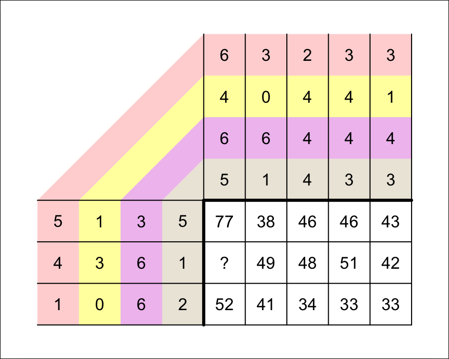

What is $c_{2,1}$?

To find $c_{2,1}$, you use row 2 from matrix $A$ and column 1 from matrix $B$.

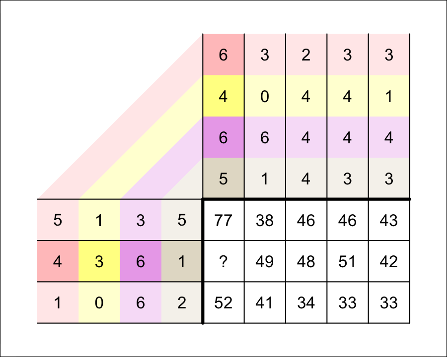

You multiply corresponding elements and sum those products.

$$c_{2,1}~=~( 4 \cdot 6 )+( 3 \cdot 4
)+( 6 \cdot 6 )+( 1 \cdot 5 )$$

$$c_{2,1}~=~24+12+36+5$$

$$c_{2,1}~=~77$$

Thus,

$$\begin{bmatrix}
5 & 1 & 3 & 5\\
4 & 3 & 6 & 1\\
1 & 0 & 6 & 2
\end{bmatrix} \cdot \begin{bmatrix}
6 & 3 & 2 & 3 & 3\\
4 & 0 & 4 & 4 & 1\\
6 & 6 & 4 & 4 & 4\\
5 & 1 & 4 & 3 & 3
\end{bmatrix} ~=~ \begin{bmatrix}
77 & 38 & 46 & 46 & 43\\
77 & 49 & 48 & 51 & 42\\
52 & 41 & 34 & 33 & 33
\end{bmatrix}$$

Let matrices $A$ and $B$ be defined below.

$$A = \begin{bmatrix}
0 & 2 & 6 & 4\\
3 & 1 & 1 & 2\\
3 & 3 & 6 & 3
\end{bmatrix}$$
$$B = \begin{bmatrix}
2 & 4 & 4 & 3 & 4\\
3 & 0 & 1 & 5 & 4\\
2 & 3 & 4 & 0 & 6\\
5 & 4 & 6 & 6 & 2
\end{bmatrix}$$

A third matrix, $C$, is equal to the [product](https://en.wikipedia.org/wiki/Matrix_multiplication) $AB$. A student set up a diagram to help find the product; they are missing a single element in $C$, element $c_{2,4}$.

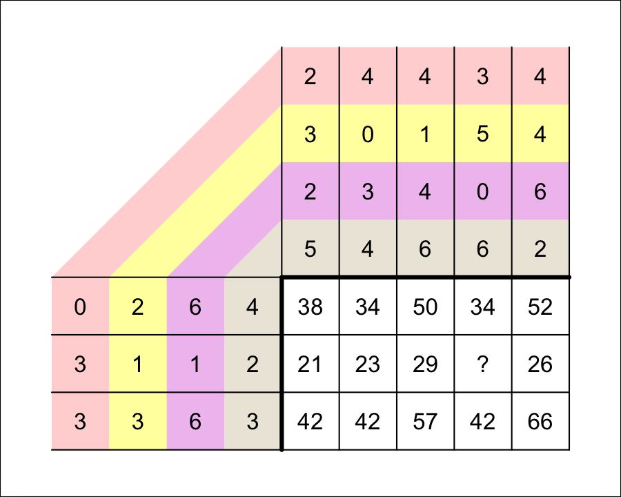

What is $c_{2,4}$?

To find $c_{2,4}$, you use row 2 from matrix $A$ and column 4 from matrix $B$.

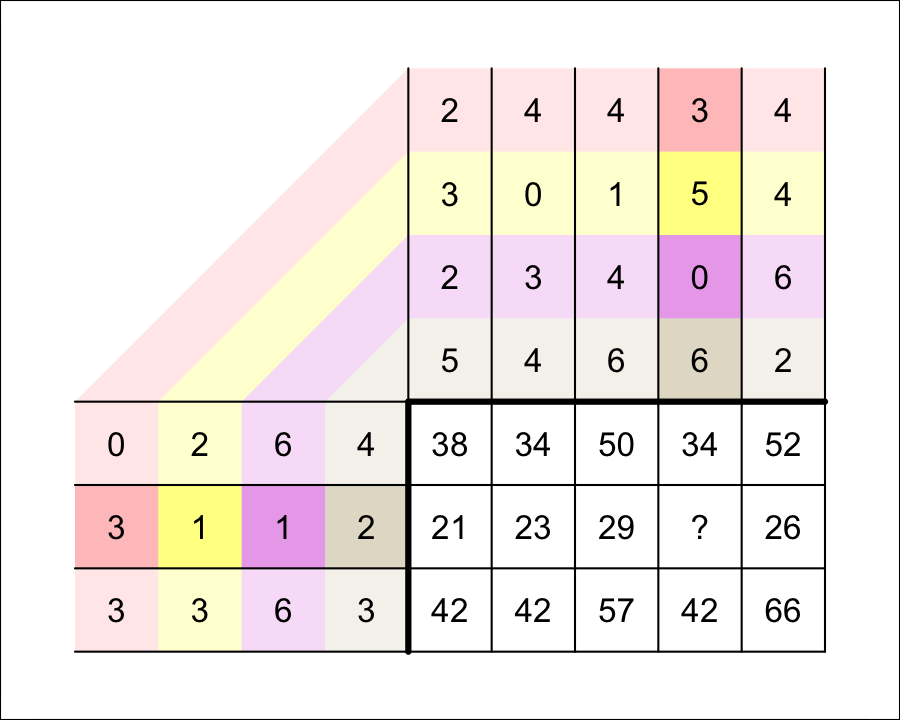

You multiply corresponding elements and sum those products.

$$c_{2,4}~=~( 3 \cdot 3 )+( 1 \cdot 5
)+( 1 \cdot 0 )+( 2 \cdot 6 )$$

$$c_{2,4}~=~9+5+0+12$$

$$c_{2,4}~=~26$$

Thus,

$$\begin{bmatrix}
0 & 2 & 6 & 4\\
3 & 1 & 1 & 2\\
3 & 3 & 6 & 3
\end{bmatrix} \cdot \begin{bmatrix}
2 & 4 & 4 & 3 & 4\\
3 & 0 & 1 & 5 & 4\\
2 & 3 & 4 & 0 & 6\\
5 & 4 & 6 & 6 & 2
\end{bmatrix} ~=~ \begin{bmatrix}
38 & 34 & 50 & 34 & 52\\
21 & 23 & 29 & 26 & 26\\
42 & 42 & 57 & 42 & 66
\end{bmatrix}$$

Let matrices $A$ and $B$ be defined below.

$$A = \begin{bmatrix}
2 & 2 & 0 & 5\\
6 & 2 & 0 & 1\\
6 & 1 & 3 & 3
\end{bmatrix}$$
$$B = \begin{bmatrix}
1 & 2 & 3 & 6 & 3\\
3 & 1 & 4 & 3 & 4\\
2 & 1 & 5 & 3 & 3\\
6 & 5 & 0 & 0 & 6
\end{bmatrix}$$

A third matrix, $C$, is equal to the [product](https://en.wikipedia.org/wiki/Matrix_multiplication) $AB$. A student set up a diagram to help find the product; they are missing a single element in $C$, element $c_{2,3}$.

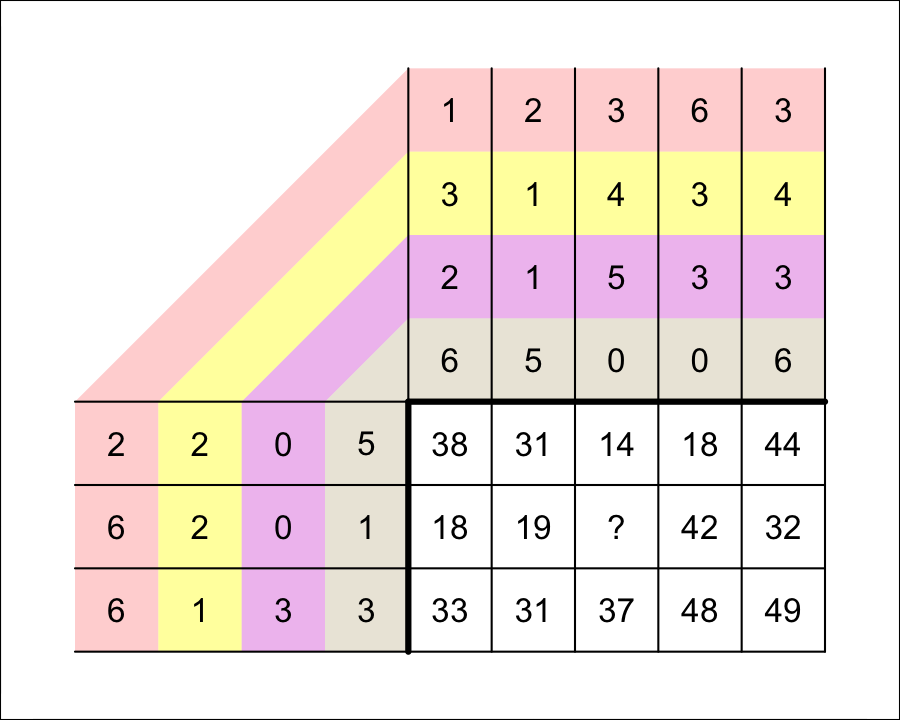

What is $c_{2,3}$?

To find $c_{2,3}$, you use row 2 from matrix $A$ and column 3 from matrix $B$.

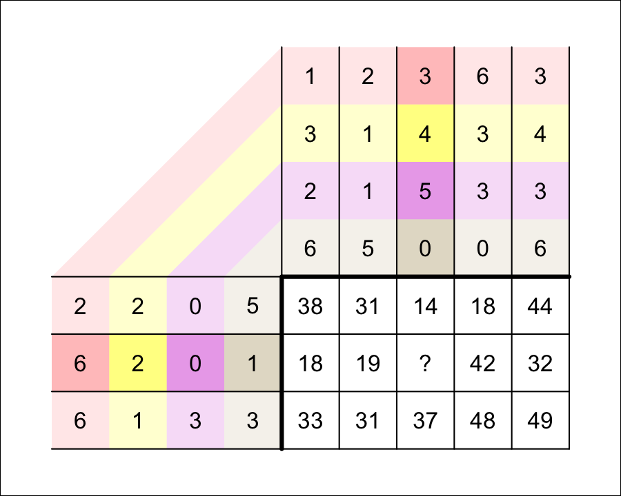

You multiply corresponding elements and sum those products.

$$c_{2,3}~=~( 6 \cdot 3 )+( 2 \cdot 4
)+( 0 \cdot 5 )+( 1 \cdot 0 )$$

$$c_{2,3}~=~18+8+0+0$$

$$c_{2,3}~=~26$$

Thus,

$$\begin{bmatrix}
2 & 2 & 0 & 5\\
6 & 2 & 0 & 1\\
6 & 1 & 3 & 3
\end{bmatrix} \cdot \begin{bmatrix}
1 & 2 & 3 & 6 & 3\\
3 & 1 & 4 & 3 & 4\\
2 & 1 & 5 & 3 & 3\\
6 & 5 & 0 & 0 & 6
\end{bmatrix} ~=~ \begin{bmatrix}
38 & 31 & 14 & 18 & 44\\
18 & 19 & 26 & 42 & 32\\
33 & 31 & 37 & 48 & 49
\end{bmatrix}$$

Let matrices $A$ and $B$ be defined below.

$$A = \begin{bmatrix}
3 & 0 & 2 & 6\\
2 & 4 & 3 & 6\\
5 & 2 & 1 & 4
\end{bmatrix}$$
$$B = \begin{bmatrix}
1 & 5 & 4 & 5 & 1\\
0 & 4 & 2 & 0 & 4\\
3 & 4 & 0 & 4 & 0\\
0 & 1 & 5 & 3 & 2
\end{bmatrix}$$

A third matrix, $C$, is equal to the [product](https://en.wikipedia.org/wiki/Matrix_multiplication) $AB$. A student set up a diagram to help find the product; they are missing a single element in $C$, element $c_{2,4}$.

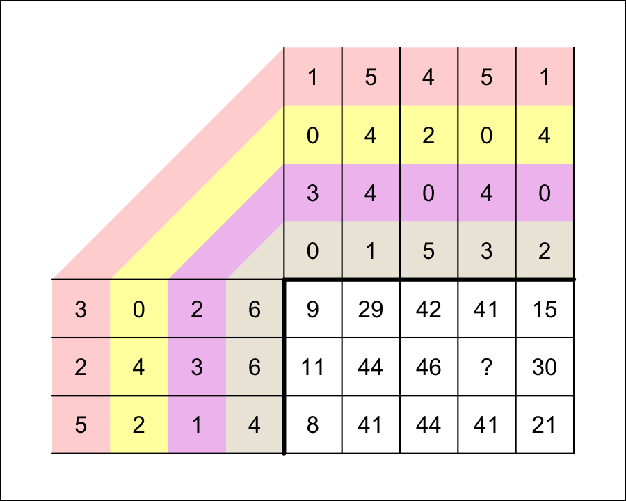

What is $c_{2,4}$?

To find $c_{2,4}$, you use row 2 from matrix $A$ and column 4 from matrix $B$.

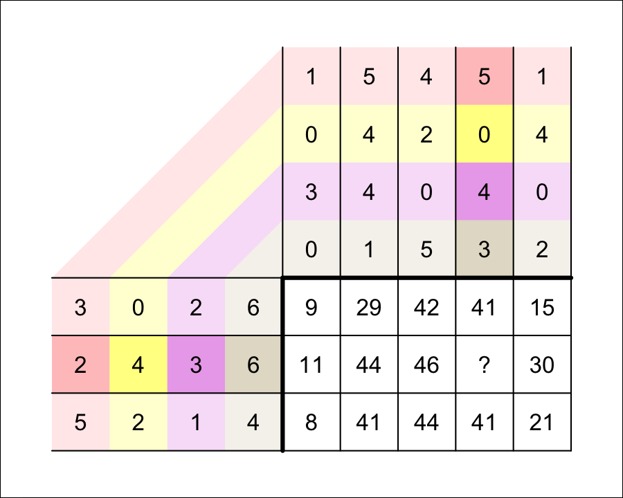

You multiply corresponding elements and sum those products.

$$c_{2,4}~=~( 2 \cdot 5 )+( 4 \cdot 0
)+( 3 \cdot 4 )+( 6 \cdot 3 )$$

$$c_{2,4}~=~10+0+12+18$$

$$c_{2,4}~=~40$$

Thus,

$$\begin{bmatrix}
3 & 0 & 2 & 6\\
2 & 4 & 3 & 6\\
5 & 2 & 1 & 4
\end{bmatrix} \cdot \begin{bmatrix}
1 & 5 & 4 & 5 & 1\\
0 & 4 & 2 & 0 & 4\\
3 & 4 & 0 & 4 & 0\\
0 & 1 & 5 & 3 & 2
\end{bmatrix} ~=~ \begin{bmatrix}
9 & 29 & 42 & 41 & 15\\
11 & 44 & 46 & 40 & 30\\
8 & 41 & 44 & 41 & 21
\end{bmatrix}$$

Let matrices $A$ and $B$ be defined below.

$$A = \begin{bmatrix}
6 & 5 & 6 & 2\\
2 & 2 & 6 & 1\\
3 & 0 & 6 & 3
\end{bmatrix}$$
$$B = \begin{bmatrix}
5 & 5 & 2 & 5 & 1\\
1 & 1 & 4 & 1 & 5\\
5 & 1 & 2 & 5 & 6\\
0 & 5 & 6 & 0 & 2
\end{bmatrix}$$

A third matrix, $C$, is equal to the [product](https://en.wikipedia.org/wiki/Matrix_multiplication) $AB$. A student set up a diagram to help find the product; they are missing a single element in $C$, element $c_{1,1}$.

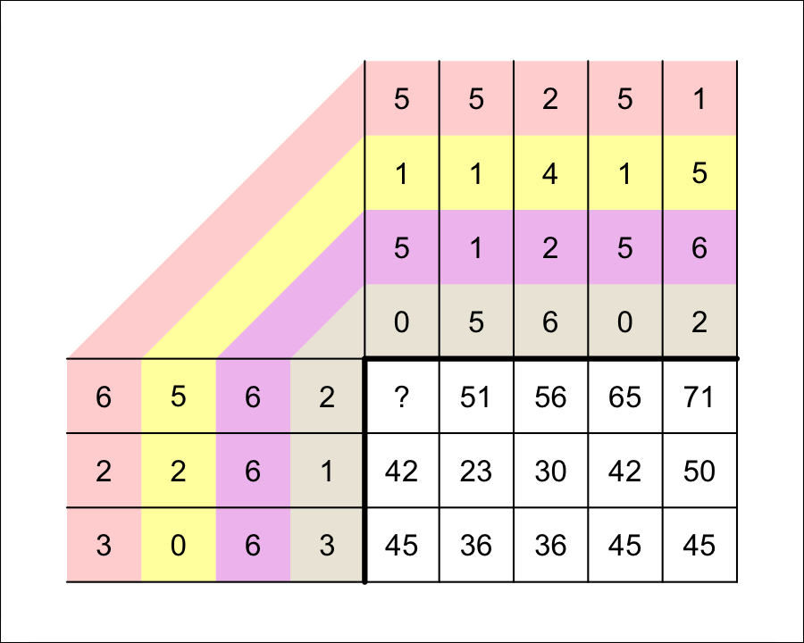

What is $c_{1,1}$?

To find $c_{1,1}$, you use row 1 from matrix $A$ and column 1 from matrix $B$.

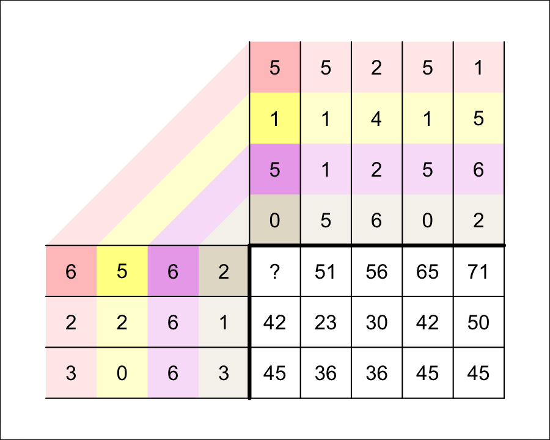

You multiply corresponding elements and sum those products.

$$c_{1,1}~=~( 6 \cdot 5 )+( 5 \cdot 1
)+( 6 \cdot 5 )+( 2 \cdot 0 )$$

$$c_{1,1}~=~30+5+30+0$$

$$c_{1,1}~=~65$$

Thus,

$$\begin{bmatrix}
6 & 5 & 6 & 2\\
2 & 2 & 6 & 1\\
3 & 0 & 6 & 3
\end{bmatrix} \cdot \begin{bmatrix}
5 & 5 & 2 & 5 & 1\\
1 & 1 & 4 & 1 & 5\\
5 & 1 & 2 & 5 & 6\\
0 & 5 & 6 & 0 & 2
\end{bmatrix} ~=~ \begin{bmatrix}
65 & 51 & 56 & 65 & 71\\
42 & 23 & 30 & 42 & 50\\
45 & 36 & 36 & 45 & 45
\end{bmatrix}$$

Let matrices $A$ and $B$ be defined below.

$$A = \begin{bmatrix}
6 & 3 & 5\\
8 & 9 & 1\\
2 & 7 & 4
\end{bmatrix}$$
$$B = \begin{bmatrix}
4 & 8 & 3\\
6 & 1 & 7\\
5 & 9 & 2
\end{bmatrix}$$

A third matrix, $C$, is equal to the [product](https://en.wikipedia.org/wiki/Matrix_multiplication) $AB$. A student set up a diagram to help find the product:

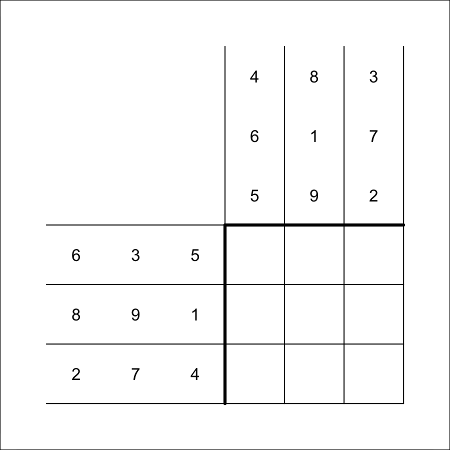

What is $c_{3,1}$?

To find $c_{3,1}$, you use row 3 from matrix $A$ and column 1 from matrix $B$.

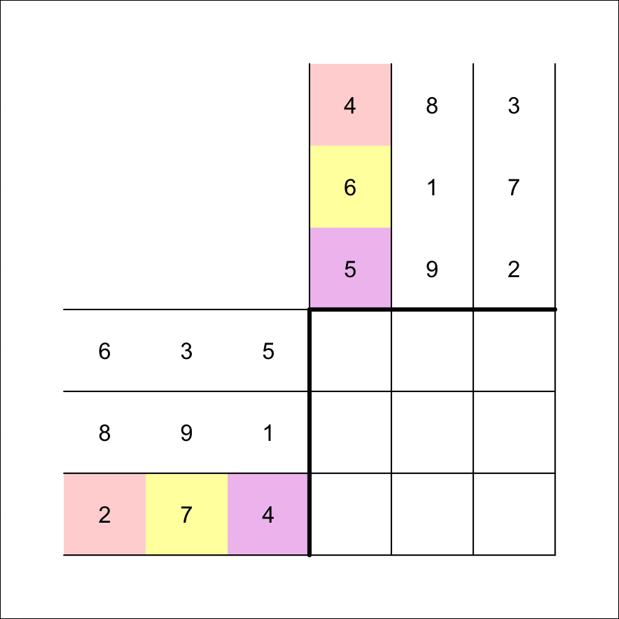

You multiply corresponding elements and sum those products.

$$c_{3,1}~=~( 2 \cdot 4 )+( 7 \cdot 6
)+( 4 \cdot 5 )$$

$$c_{3,1}~=~8+42+20$$

$$c_{3,1}~=~70$$

If you repeat this process for all 9 elements in $C$, you get:

$$\begin{bmatrix}
6 & 3 & 5\\
8 & 9 & 1\\
2 & 7 & 4
\end{bmatrix} \cdot \begin{bmatrix}
4 & 8 & 3\\
6 & 1 & 7\\
5 & 9 & 2
\end{bmatrix} ~=~ \begin{bmatrix}
67 & 96 & 49\\
91 & 82 & 89\\
70 & 59 & 63
\end{bmatrix}$$

Let matrices $A$ and $B$ be defined below.

$$A = \begin{bmatrix}
2 & 7 & 1\\
3 & 5 & 8\\
6 & 9 & 4
\end{bmatrix}$$
$$B = \begin{bmatrix}
9 & 5 & 2\\
3 & 8 & 1\\
7 & 4 & 6
\end{bmatrix}$$

A third matrix, $C$, is equal to the [product](https://en.wikipedia.org/wiki/Matrix_multiplication) $AB$. A student set up a diagram to help find the product:

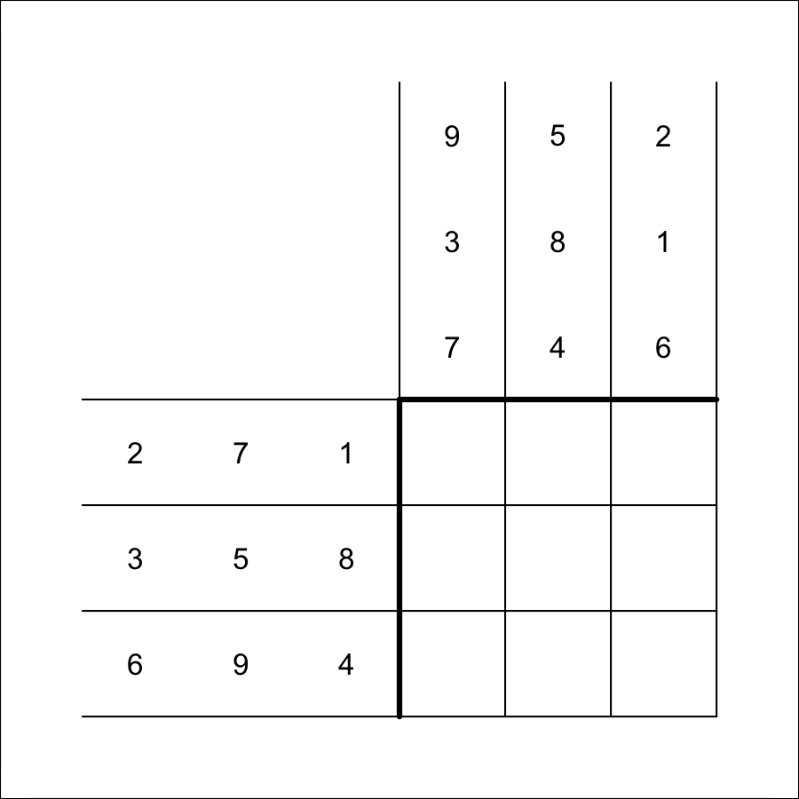

What is $c_{3,2}$?

To find $c_{3,2}$, you use row 3 from matrix $A$ and column 2 from matrix $B$.

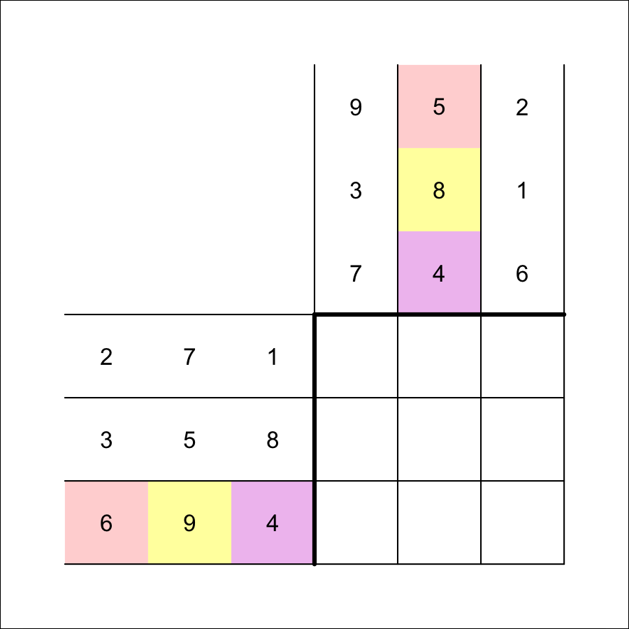

You multiply corresponding elements and sum those products.

$$c_{3,2}~=~( 6 \cdot 5 )+( 9 \cdot 8
)+( 4 \cdot 4 )$$

$$c_{3,2}~=~30+72+16$$

$$c_{3,2}~=~118$$

If you repeat this process for all 9 elements in $C$, you get:

$$\begin{bmatrix}
2 & 7 & 1\\
3 & 5 & 8\\
6 & 9 & 4
\end{bmatrix} \cdot \begin{bmatrix}
9 & 5 & 2\\
3 & 8 & 1\\
7 & 4 & 6
\end{bmatrix} ~=~ \begin{bmatrix}
46 & 70 & 17\\
98 & 87 & 59\\
109 & 118 & 45
\end{bmatrix}$$

Let matrices $A$ and $B$ be defined below.

$$A = \begin{bmatrix}
7 & 8 & 2\\
9 & 5 & 6\\
4 & 1 & 3
\end{bmatrix}$$
$$B = \begin{bmatrix}
1 & 4 & 6\\
9 & 5 & 8\\
3 & 7 & 2
\end{bmatrix}$$

A third matrix, $C$, is equal to the [product](https://en.wikipedia.org/wiki/Matrix_multiplication) $AB$. A student set up a diagram to help find the product:

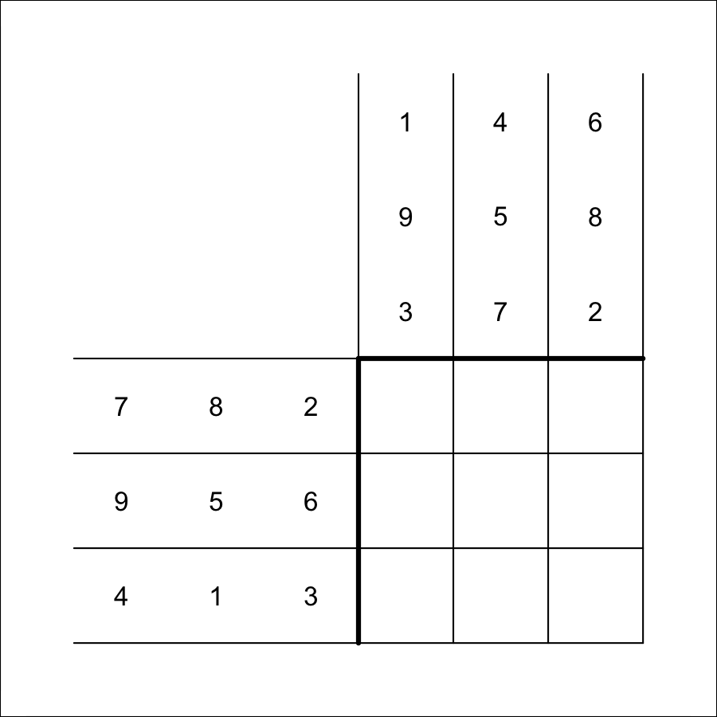

What is $c_{2,3}$?

To find $c_{2,3}$, you use row 2 from matrix $A$ and column 3 from matrix $B$.

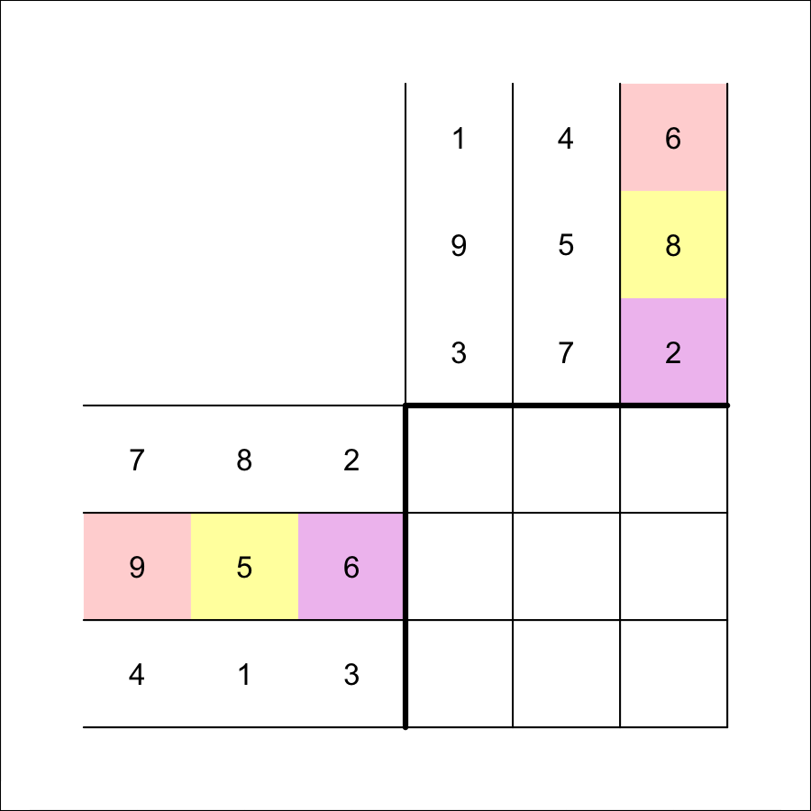

You multiply corresponding elements and sum those products.

$$c_{2,3}~=~( 9 \cdot 6 )+( 5 \cdot 8
)+( 6 \cdot 2 )$$

$$c_{2,3}~=~54+40+12$$

$$c_{2,3}~=~106$$

If you repeat this process for all 9 elements in $C$, you get:

$$\begin{bmatrix}
7 & 8 & 2\\
9 & 5 & 6\\
4 & 1 & 3
\end{bmatrix} \cdot \begin{bmatrix}
1 & 4 & 6\\
9 & 5 & 8\\
3 & 7 & 2
\end{bmatrix} ~=~ \begin{bmatrix}
85 & 82 & 110\\
72 & 103 & 106\\
22 & 42 & 38
\end{bmatrix}$$

Let matrices $A$ and $B$ be defined below.

$$A = \begin{bmatrix}
8 & 9 & 4\\
6 & 2 & 7\\
1 & 5 & 3
\end{bmatrix}$$
$$B = \begin{bmatrix}
3 & 7 & 9\\
8 & 2 & 5\\
4 & 1 & 6
\end{bmatrix}$$

A third matrix, $C$, is equal to the [product](https://en.wikipedia.org/wiki/Matrix_multiplication) $AB$. A student set up a diagram to help find the product:

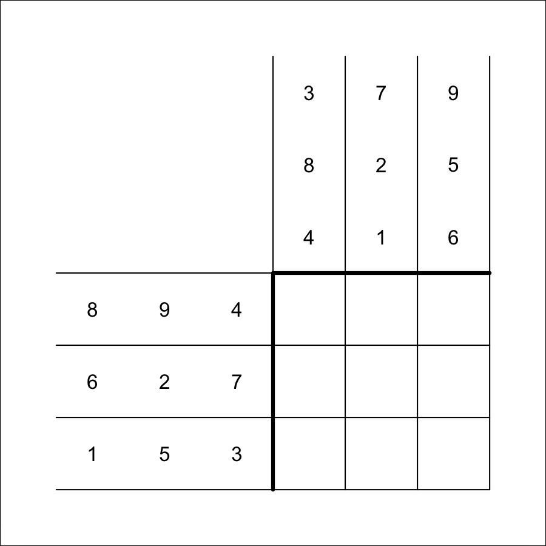

What is $c_{3,1}$?

To find $c_{3,1}$, you use row 3 from matrix $A$ and column 1 from matrix $B$.

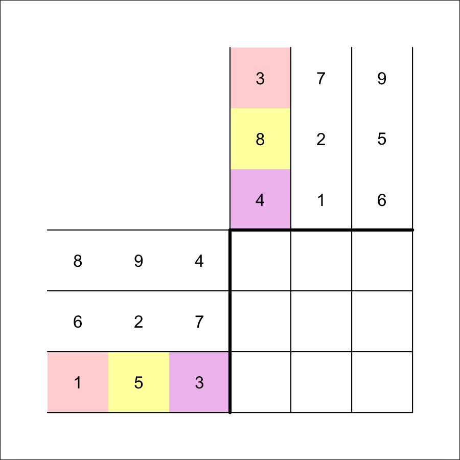

You multiply corresponding elements and sum those products.

$$c_{3,1}~=~( 1 \cdot 3 )+( 5 \cdot 8
)+( 3 \cdot 4 )$$

$$c_{3,1}~=~3+40+12$$

$$c_{3,1}~=~55$$

If you repeat this process for all 9 elements in $C$, you get:

$$\begin{bmatrix}
8 & 9 & 4\\
6 & 2 & 7\\
1 & 5 & 3
\end{bmatrix} \cdot \begin{bmatrix}
3 & 7 & 9\\
8 & 2 & 5\\
4 & 1 & 6
\end{bmatrix} ~=~ \begin{bmatrix}
112 & 78 & 141\\
62 & 53 & 106\\
55 & 20 & 52
\end{bmatrix}$$

Let matrices $A$ and $B$ be defined below.

$$A = \begin{bmatrix}
1 & 2 & 5\\
4 & 3 & 9\\
8 & 7 & 6
\end{bmatrix}$$
$$B = \begin{bmatrix}
3 & 5 & 8\\
7 & 2 & 1\\
9 & 6 & 4
\end{bmatrix}$$

A third matrix, $C$, is equal to the [product](https://en.wikipedia.org/wiki/Matrix_multiplication) $AB$. A student set up a diagram to help find the product:

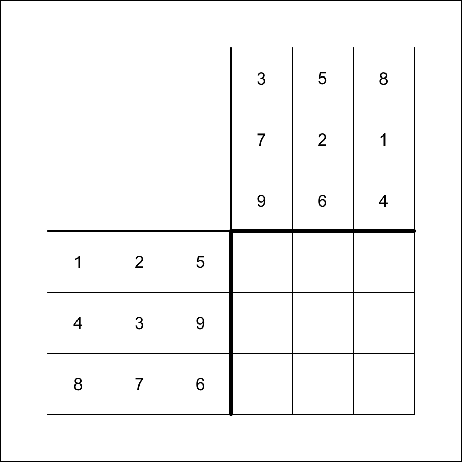

What is $c_{2,3}$?

To find $c_{2,3}$, you use row 2 from matrix $A$ and column 3 from matrix $B$.

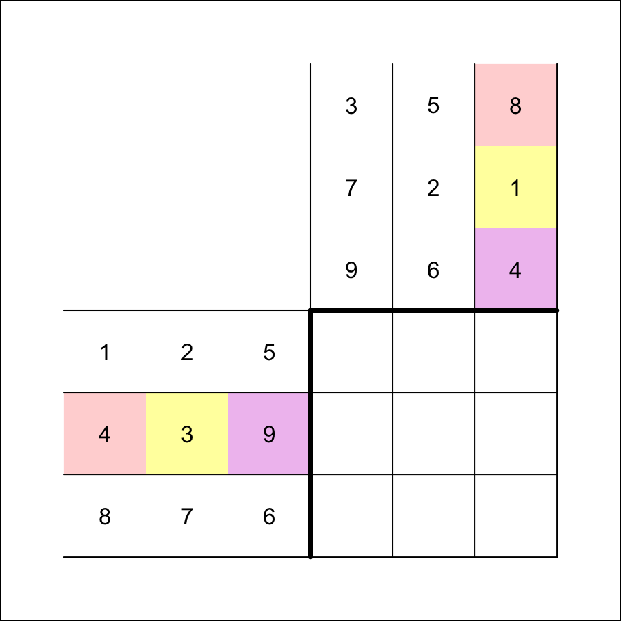

You multiply corresponding elements and sum those products.

$$c_{2,3}~=~( 4 \cdot 8 )+( 3 \cdot 1
)+( 9 \cdot 4 )$$

$$c_{2,3}~=~32+3+36$$

$$c_{2,3}~=~71$$

If you repeat this process for all 9 elements in $C$, you get:

$$\begin{bmatrix}
1 & 2 & 5\\
4 & 3 & 9\\
8 & 7 & 6
\end{bmatrix} \cdot \begin{bmatrix}
3 & 5 & 8\\
7 & 2 & 1\\
9 & 6 & 4
\end{bmatrix} ~=~ \begin{bmatrix}
62 & 39 & 30\\
114 & 80 & 71\\
127 & 90 & 95
\end{bmatrix}$$

Let matrices $A$ and $B$ be defined below.

$$A = \begin{bmatrix}
9 & 5 & 4\\
2 & 7 & 8\\
1 & 6 & 3
\end{bmatrix}$$
$$B = \begin{bmatrix}
8 & 3 & 1\\
2 & 7 & 5\\
9 & 6 & 4
\end{bmatrix}$$

A third matrix, $C$, is equal to the [product](https://en.wikipedia.org/wiki/Matrix_multiplication) $AB$. A student set up a diagram to help find the product:

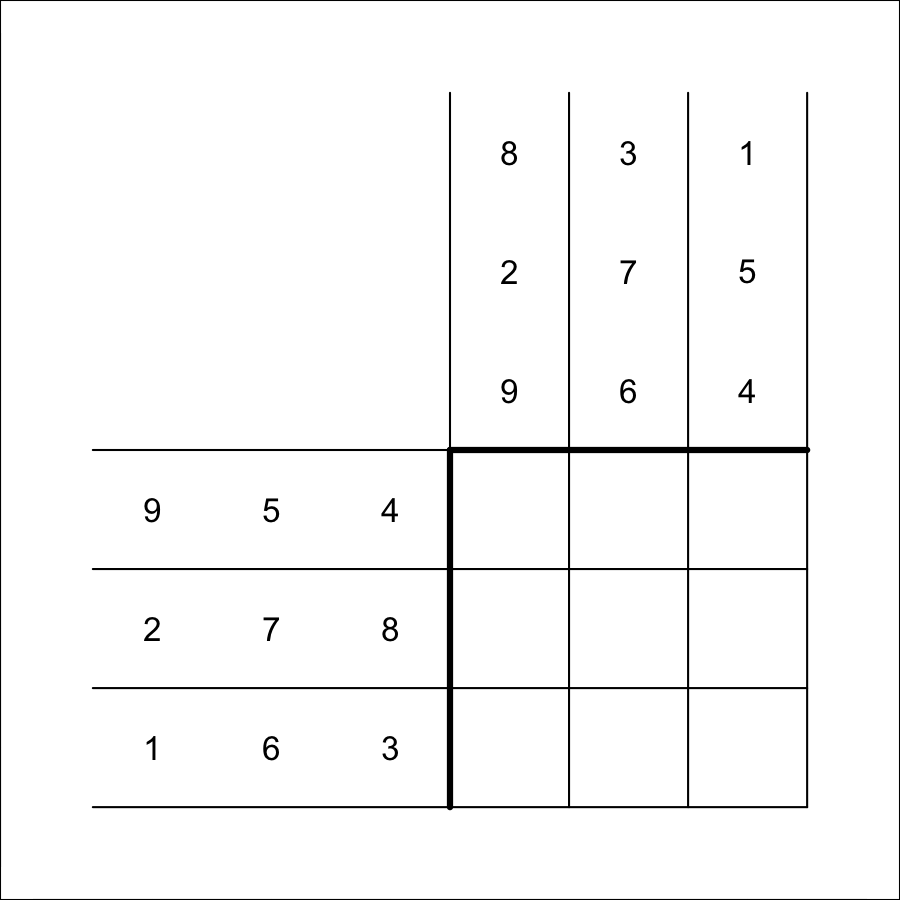

What is $c_{2,3}$?

To find $c_{2,3}$, you use row 2 from matrix $A$ and column 3 from matrix $B$.

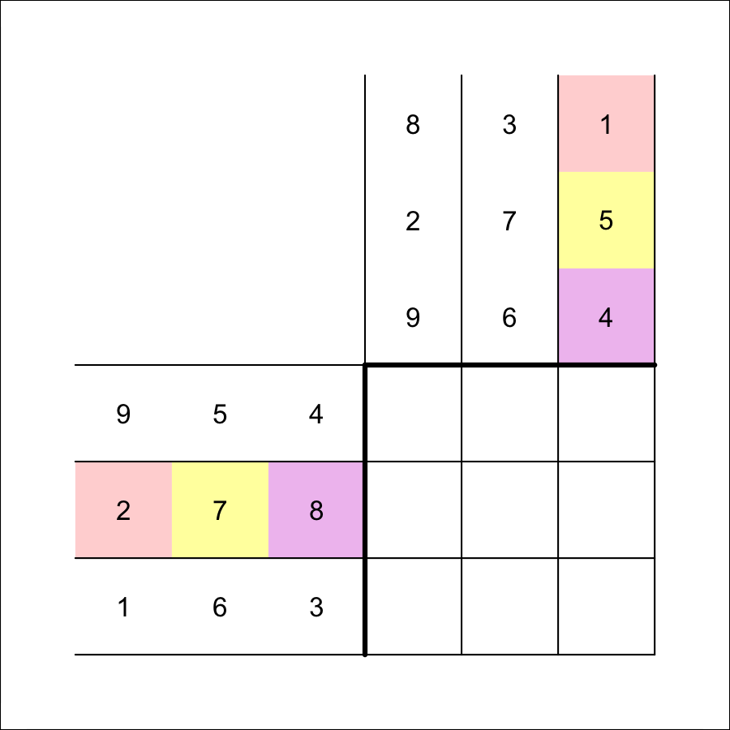

You multiply corresponding elements and sum those products.

$$c_{2,3}~=~( 2 \cdot 1 )+( 7 \cdot 5
)+( 8 \cdot 4 )$$

$$c_{2,3}~=~2+35+32$$

$$c_{2,3}~=~69$$

If you repeat this process for all 9 elements in $C$, you get:

$$\begin{bmatrix}
9 & 5 & 4\\
2 & 7 & 8\\
1 & 6 & 3
\end{bmatrix} \cdot \begin{bmatrix}
8 & 3 & 1\\
2 & 7 & 5\\
9 & 6 & 4
\end{bmatrix} ~=~ \begin{bmatrix}
118 & 86 & 50\\
102 & 103 & 69\\
47 & 63 & 43
\end{bmatrix}$$

Let matrices $A$ and $B$ be defined below.

$$A = \begin{bmatrix}
9 & 8 & 1\\
2 & 5 & 4\\
3 & 7 & 6
\end{bmatrix}$$
$$B = \begin{bmatrix}
4 & 6 & 7\\
8 & 3 & 9\\
5 & 2 & 1
\end{bmatrix}$$

A third matrix, $C$, is equal to the [product](https://en.wikipedia.org/wiki/Matrix_multiplication) $AB$. A student set up a diagram to help find the product:

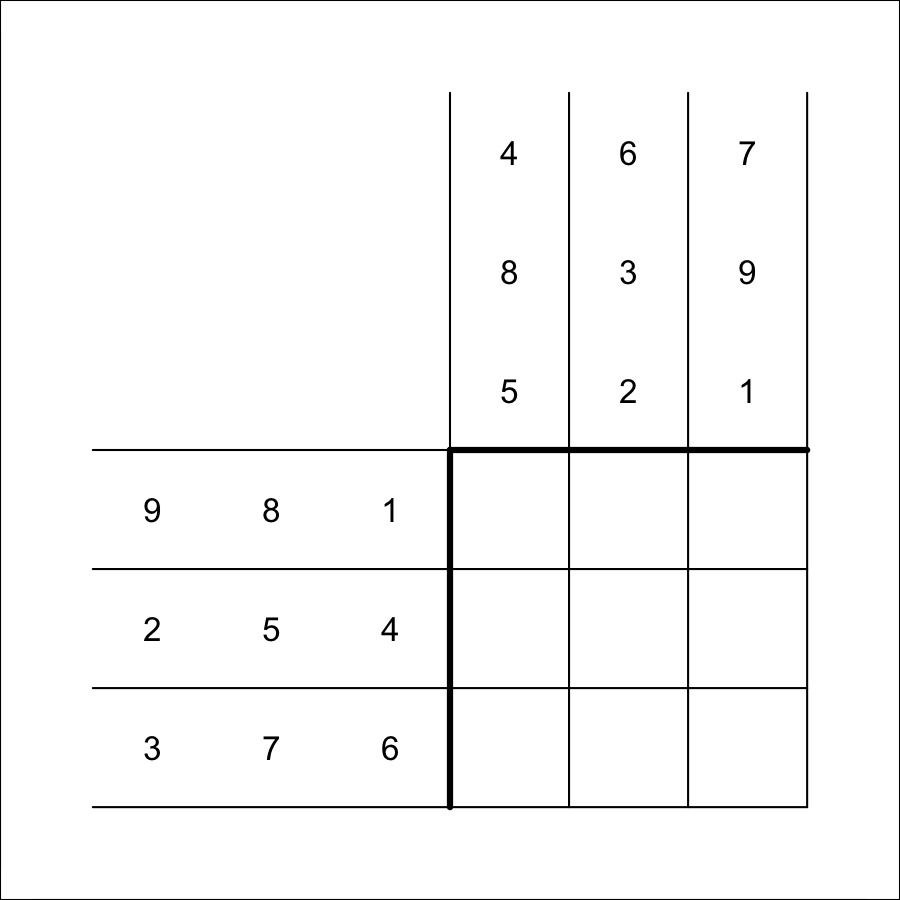

What is $c_{1,3}$?

To find $c_{1,3}$, you use row 1 from matrix $A$ and column 3 from matrix $B$.

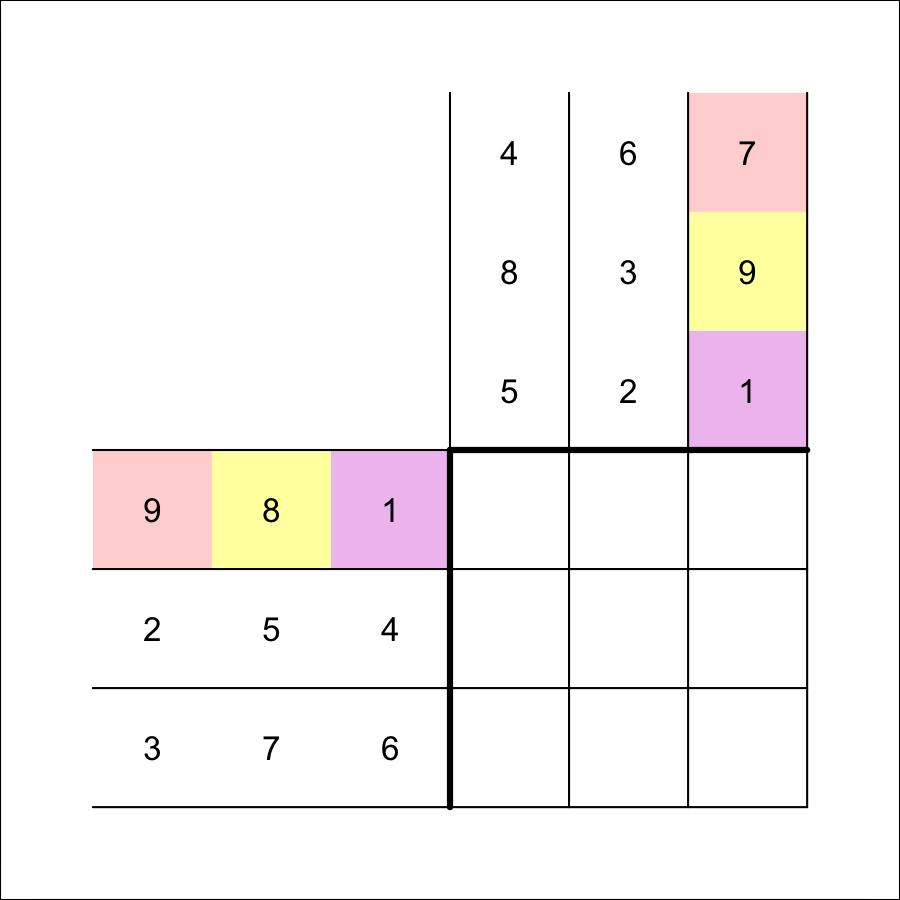

You multiply corresponding elements and sum those products.

$$c_{1,3}~=~( 9 \cdot 7 )+( 8 \cdot 9
)+( 1 \cdot 1 )$$

$$c_{1,3}~=~63+72+1$$

$$c_{1,3}~=~136$$

If you repeat this process for all 9 elements in $C$, you get:

$$\begin{bmatrix}
9 & 8 & 1\\
2 & 5 & 4\\
3 & 7 & 6
\end{bmatrix} \cdot \begin{bmatrix}
4 & 6 & 7\\
8 & 3 & 9\\
5 & 2 & 1
\end{bmatrix} ~=~ \begin{bmatrix}
105 & 80 & 136\\
68 & 35 & 63\\
98 & 51 & 90
\end{bmatrix}$$

Let matrices $A$ and $B$ be defined below.

$$A = \begin{bmatrix}
2 & 3 & 9\\
7 & 6 & 5\\
8 & 4 & 1
\end{bmatrix}$$
$$B = \begin{bmatrix}
8 & 7 & 1\\
9 & 6 & 2\\
3 & 4 & 5
\end{bmatrix}$$

A third matrix, $C$, is equal to the [product](https://en.wikipedia.org/wiki/Matrix_multiplication) $AB$. A student set up a diagram to help find the product:

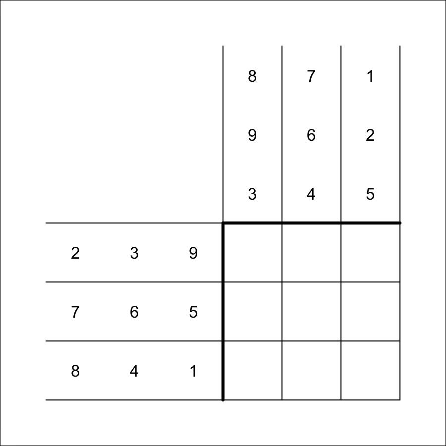

What is $c_{1,2}$?

To find $c_{1,2}$, you use row 1 from matrix $A$ and column 2 from matrix $B$.

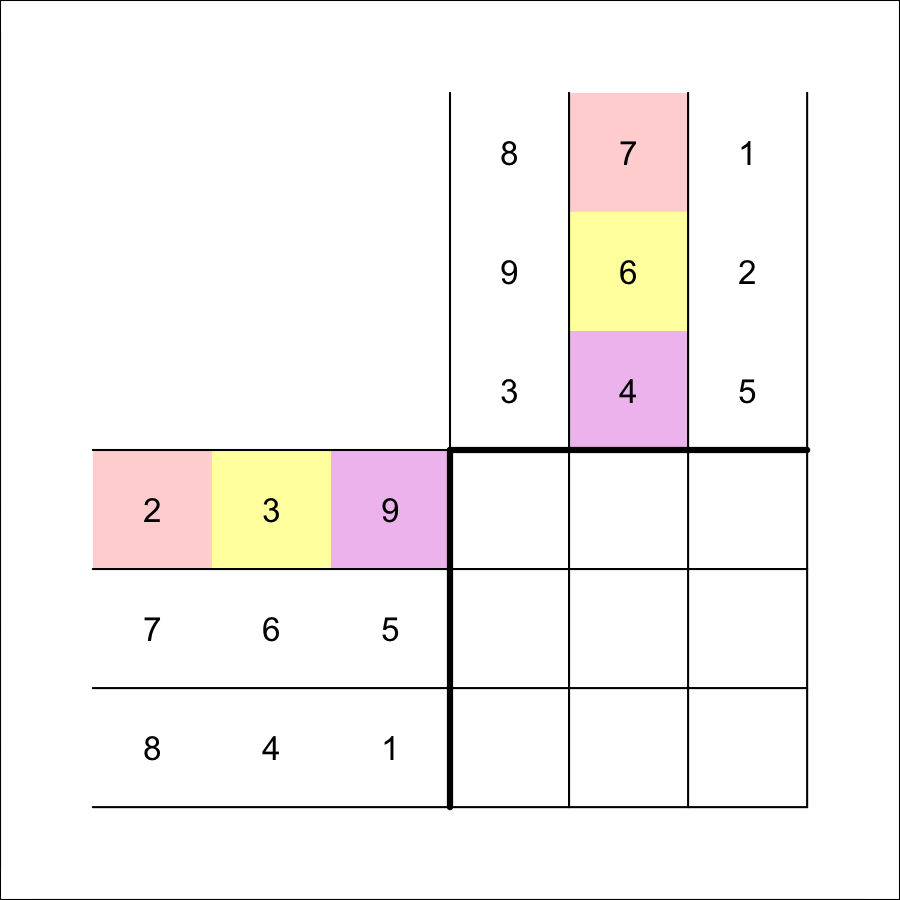

You multiply corresponding elements and sum those products.

$$c_{1,2}~=~( 2 \cdot 7 )+( 3 \cdot 6
)+( 9 \cdot 4 )$$

$$c_{1,2}~=~14+18+36$$

$$c_{1,2}~=~68$$

If you repeat this process for all 9 elements in $C$, you get:

$$\begin{bmatrix}
2 & 3 & 9\\
7 & 6 & 5\\
8 & 4 & 1
\end{bmatrix} \cdot \begin{bmatrix}
8 & 7 & 1\\
9 & 6 & 2\\
3 & 4 & 5
\end{bmatrix} ~=~ \begin{bmatrix}
70 & 68 & 53\\
125 & 105 & 44\\
103 & 84 & 21
\end{bmatrix}$$

Let matrices $A$ and $B$ be defined below.

$$A = \begin{bmatrix}
3 & 2 & 9\\
7 & 1 & 6\\
8 & 5 & 4
\end{bmatrix}$$
$$B = \begin{bmatrix}
5 & 1 & 8\\
2 & 4 & 9\\
3 & 7 & 6
\end{bmatrix}$$

A third matrix, $C$, is equal to the [product](https://en.wikipedia.org/wiki/Matrix_multiplication) $AB$. A student set up a diagram to help find the product:

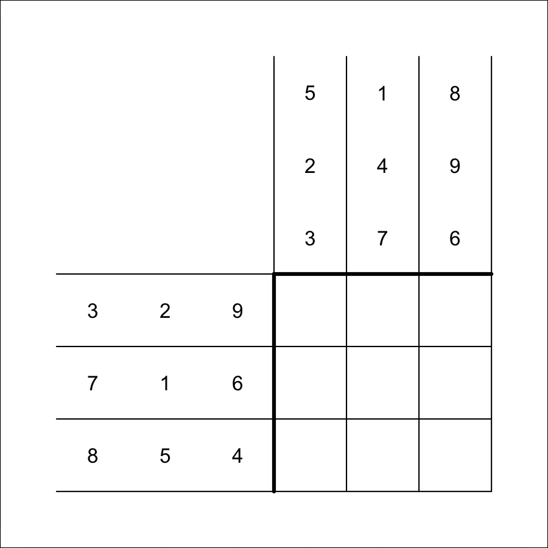

What is $c_{2,1}$?

To find $c_{2,1}$, you use row 2 from matrix $A$ and column 1 from matrix $B$.

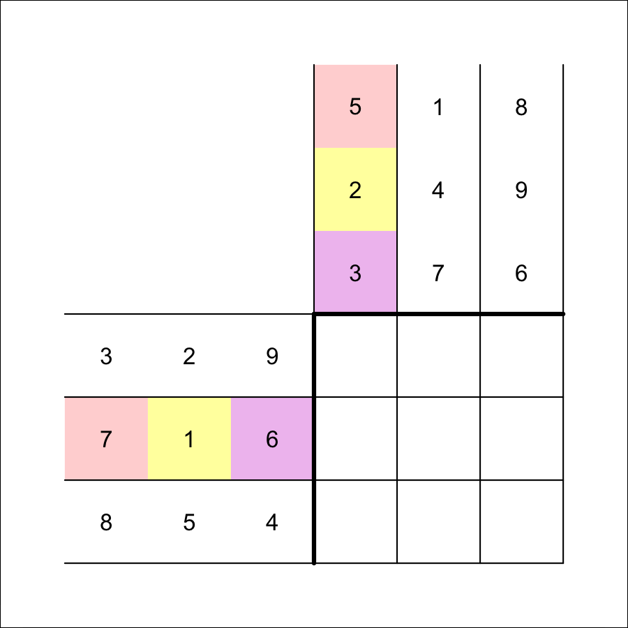

You multiply corresponding elements and sum those products.

$$c_{2,1}~=~( 7 \cdot 5 )+( 1 \cdot 2
)+( 6 \cdot 3 )$$

$$c_{2,1}~=~35+2+18$$

$$c_{2,1}~=~55$$

If you repeat this process for all 9 elements in $C$, you get:

$$\begin{bmatrix}
3 & 2 & 9\\
7 & 1 & 6\\
8 & 5 & 4
\end{bmatrix} \cdot \begin{bmatrix}
5 & 1 & 8\\
2 & 4 & 9\\
3 & 7 & 6
\end{bmatrix} ~=~ \begin{bmatrix}
46 & 74 & 96\\
55 & 53 & 101\\
62 & 56 & 133
\end{bmatrix}$$

Let matrices $A$ and $B$ be defined below.

$$A = \begin{bmatrix}
4 & 7 & 9\\
8 & 1 & 3\\
2 & 6 & 5
\end{bmatrix}$$
$$B = \begin{bmatrix}
3 & 4 & 2\\
6 & 1 & 5\\
7 & 8 & 9
\end{bmatrix}$$

A third matrix, $C$, is equal to the [product](https://en.wikipedia.org/wiki/Matrix_multiplication) $AB$. A student set up a diagram to help find the product:

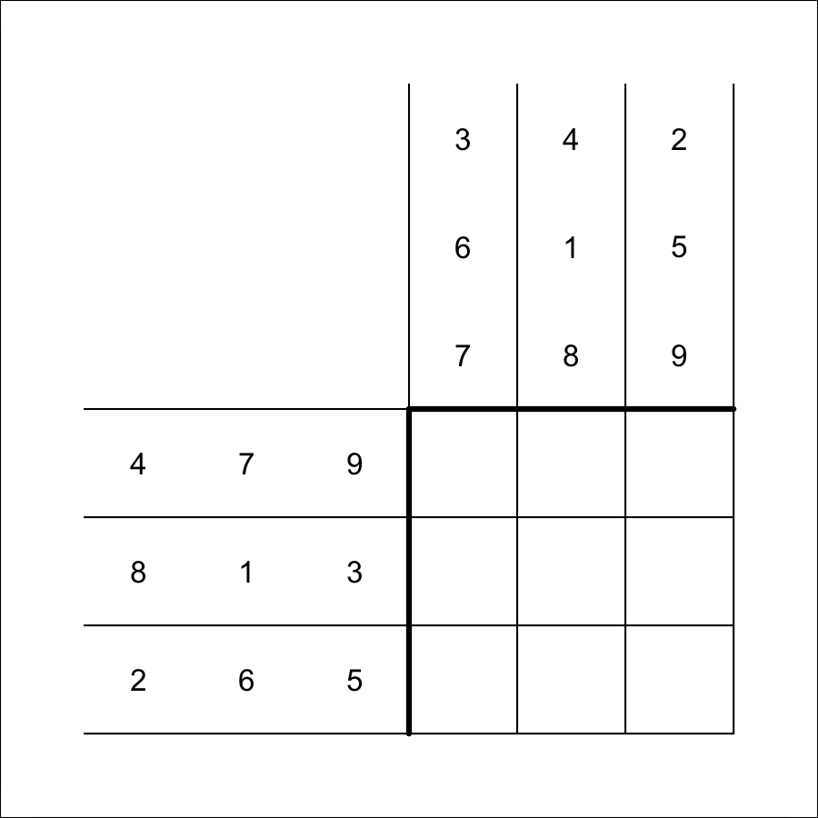

What is $c_{3,1}$?

To find $c_{3,1}$, you use row 3 from matrix $A$ and column 1 from matrix $B$.

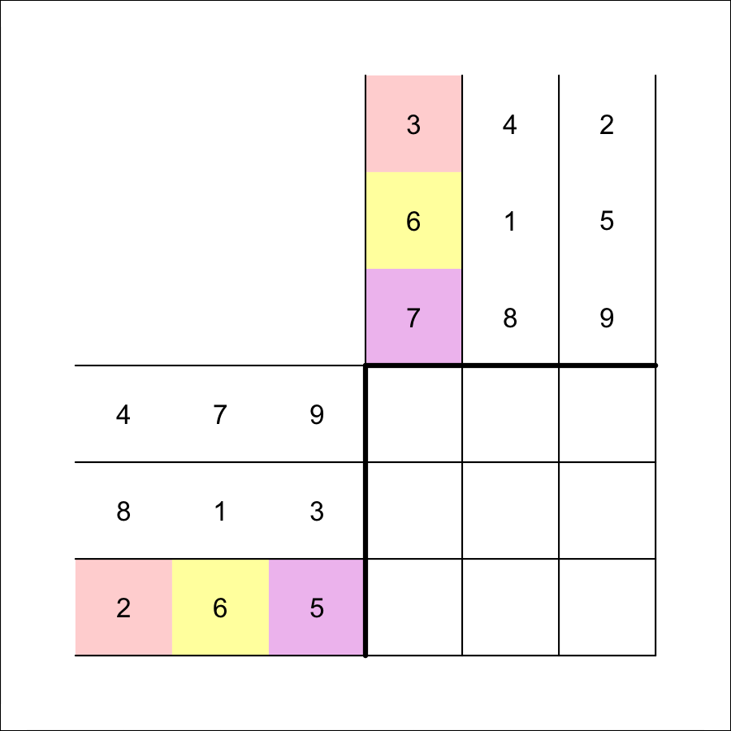

You multiply corresponding elements and sum those products.

$$c_{3,1}~=~( 2 \cdot 3 )+( 6 \cdot 6
)+( 5 \cdot 7 )$$

$$c_{3,1}~=~6+36+35$$

$$c_{3,1}~=~77$$

If you repeat this process for all 9 elements in $C$, you get:

$$\begin{bmatrix}
4 & 7 & 9\\
8 & 1 & 3\\
2 & 6 & 5
\end{bmatrix} \cdot \begin{bmatrix}
3 & 4 & 2\\
6 & 1 & 5\\
7 & 8 & 9
\end{bmatrix} ~=~ \begin{bmatrix}
117 & 95 & 124\\
51 & 57 & 48\\
77 & 54 & 79
\end{bmatrix}$$

Let matrices $A$ and $B$ be defined below.

$$A = \begin{bmatrix}
2 & 1 & 7\\
4 & 3 & 5\\
8 & 6 & 9
\end{bmatrix}$$
$$B = \begin{bmatrix}
2 & 5 & 3\\
1 & 7 & 9\\
6 & 8 & 4
\end{bmatrix}$$

A third matrix, $C$, is equal to the [product](https://en.wikipedia.org/wiki/Matrix_multiplication) $AB$. A student set up a diagram to help find the product:

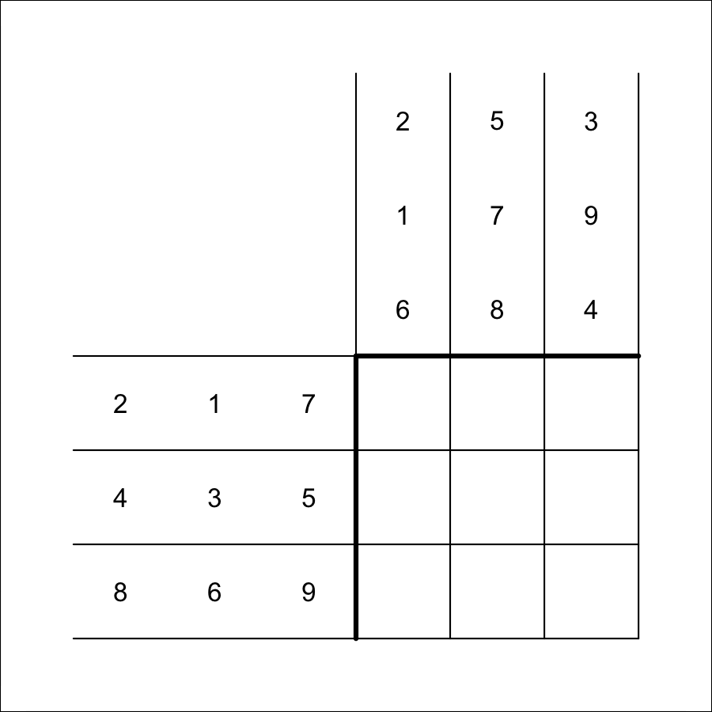

What is $c_{1,3}$?

To find $c_{1,3}$, you use row 1 from matrix $A$ and column 3 from matrix $B$.

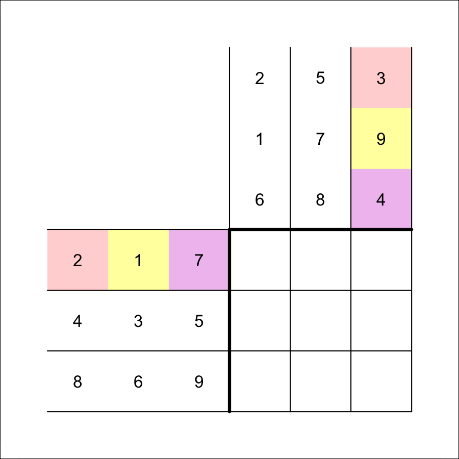

You multiply corresponding elements and sum those products.

$$c_{1,3}~=~( 2 \cdot 3 )+( 1 \cdot 9
)+( 7 \cdot 4 )$$

$$c_{1,3}~=~6+9+28$$

$$c_{1,3}~=~43$$

If you repeat this process for all 9 elements in $C$, you get:

$$\begin{bmatrix}
2 & 1 & 7\\
4 & 3 & 5\\
8 & 6 & 9
\end{bmatrix} \cdot \begin{bmatrix}
2 & 5 & 3\\
1 & 7 & 9\\
6 & 8 & 4
\end{bmatrix} ~=~ \begin{bmatrix}
47 & 73 & 43\\
41 & 81 & 59\\
76 & 154 & 114
\end{bmatrix}$$

Let matrices $A$ and $B$ be defined below.

$$A = \begin{bmatrix}
8 & 1 & 4\\
2 & 3 & 5\\
9 & 7 & 6
\end{bmatrix}$$
$$B = \begin{bmatrix}
8 & 2 & 5\\
3 & 9 & 1\\
6 & 4 & 7
\end{bmatrix}$$

A third matrix, $C$, is equal to the [product](https://en.wikipedia.org/wiki/Matrix_multiplication) $AB$. A student set up a diagram to help find the product:

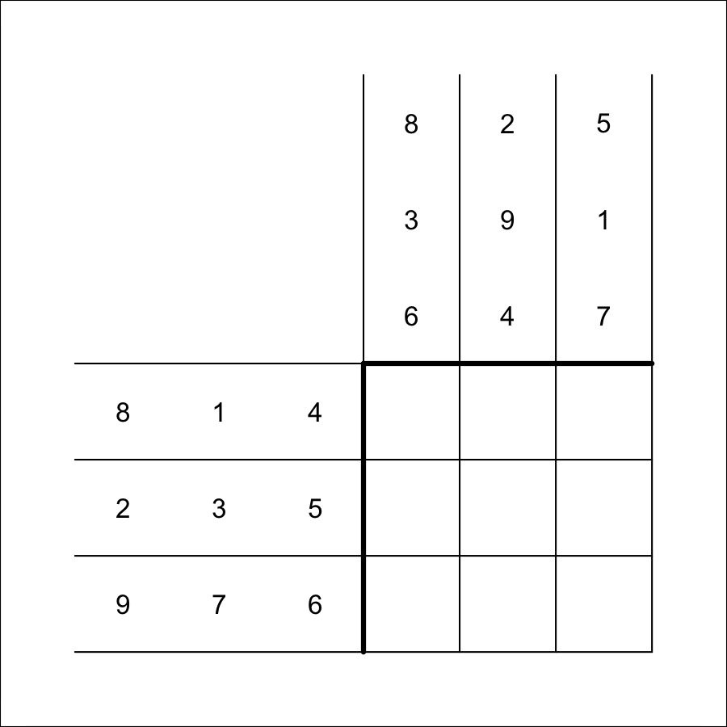

What is $c_{1,2}$?

To find $c_{1,2}$, you use row 1 from matrix $A$ and column 2 from matrix $B$.

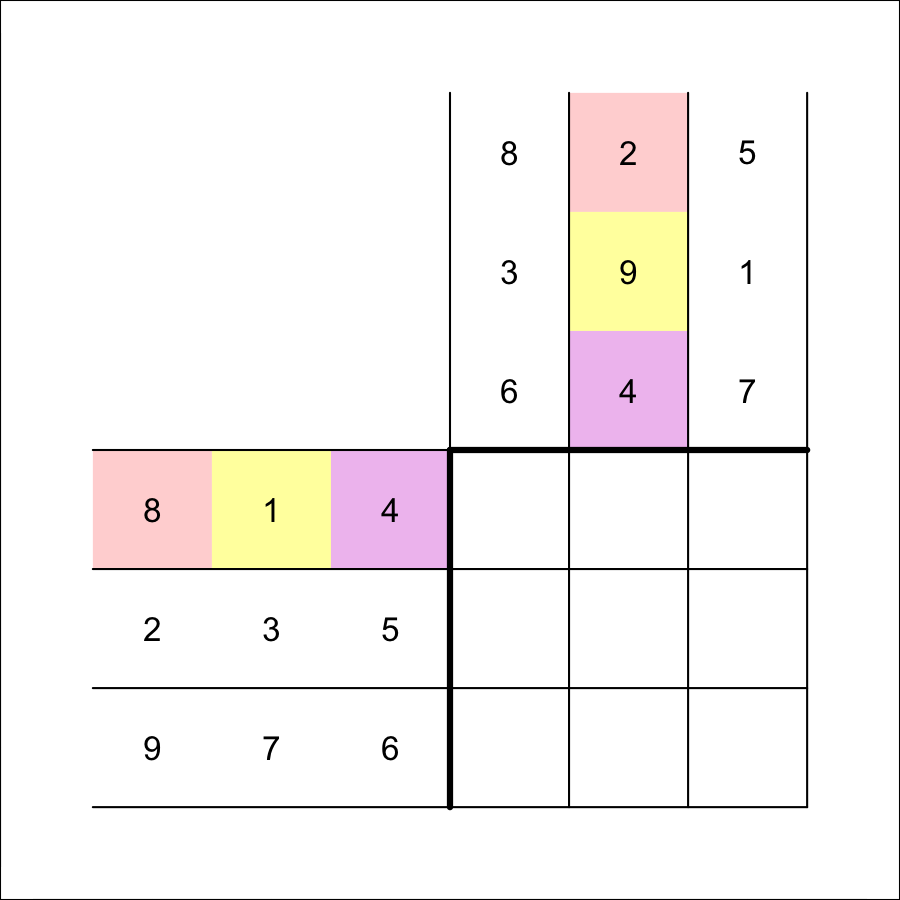

You multiply corresponding elements and sum those products.

$$c_{1,2}~=~( 8 \cdot 2 )+( 1 \cdot 9
)+( 4 \cdot 4 )$$

$$c_{1,2}~=~16+9+16$$

$$c_{1,2}~=~41$$

If you repeat this process for all 9 elements in $C$, you get:

$$\begin{bmatrix}
8 & 1 & 4\\
2 & 3 & 5\\
9 & 7 & 6
\end{bmatrix} \cdot \begin{bmatrix}
8 & 2 & 5\\
3 & 9 & 1\\
6 & 4 & 7
\end{bmatrix} ~=~ \begin{bmatrix}
91 & 41 & 69\\
55 & 51 & 48\\
129 & 105 & 94
\end{bmatrix}$$

Let matrices $A$ and $B$ be defined below.

$$A = \begin{bmatrix}
9 & 1 & 7\\
4 & 8 & 2\\
5 & 6 & 3
\end{bmatrix}$$
$$B = \begin{bmatrix}
4 & 8 & 5\\
1 & 7 & 2\\
3 & 9 & 6
\end{bmatrix}$$

A third matrix, $C$, is equal to the [product](https://en.wikipedia.org/wiki/Matrix_multiplication) $AB$. A student set up a diagram to help find the product:

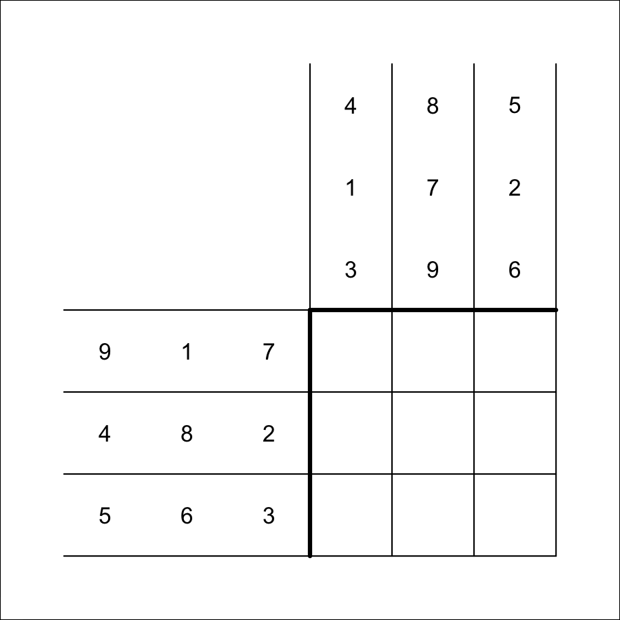

What is $c_{3,2}$?

To find $c_{3,2}$, you use row 3 from matrix $A$ and column 2 from matrix $B$.

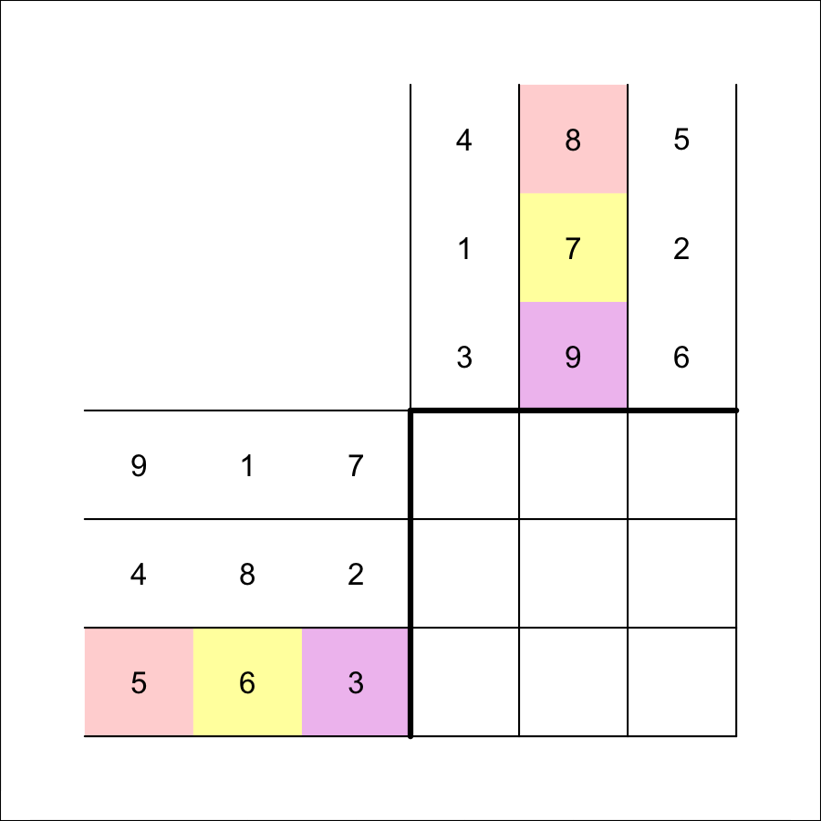

You multiply corresponding elements and sum those products.

$$c_{3,2}~=~( 5 \cdot 8 )+( 6 \cdot 7
)+( 3 \cdot 9 )$$

$$c_{3,2}~=~40+42+27$$

$$c_{3,2}~=~109$$

If you repeat this process for all 9 elements in $C$, you get:

$$\begin{bmatrix}
9 & 1 & 7\\
4 & 8 & 2\\
5 & 6 & 3
\end{bmatrix} \cdot \begin{bmatrix}
4 & 8 & 5\\
1 & 7 & 2\\
3 & 9 & 6
\end{bmatrix} ~=~ \begin{bmatrix}
58 & 142 & 89\\
30 & 106 & 48\\
35 & 109 & 55
\end{bmatrix}$$

Let matrices $A$ and $B$ be defined below.

$$A = \begin{bmatrix}
7 & 1 & 9\\
5 & 3 & 8\\
6 & 2 & 4
\end{bmatrix}$$
$$B = \begin{bmatrix}
7 & 1 & 8\\
3 & 4 & 6\\
2 & 9 & 5
\end{bmatrix}$$

A third matrix, $C$, is equal to the [product](https://en.wikipedia.org/wiki/Matrix_multiplication) $AB$. A student set up a diagram to help find the product:

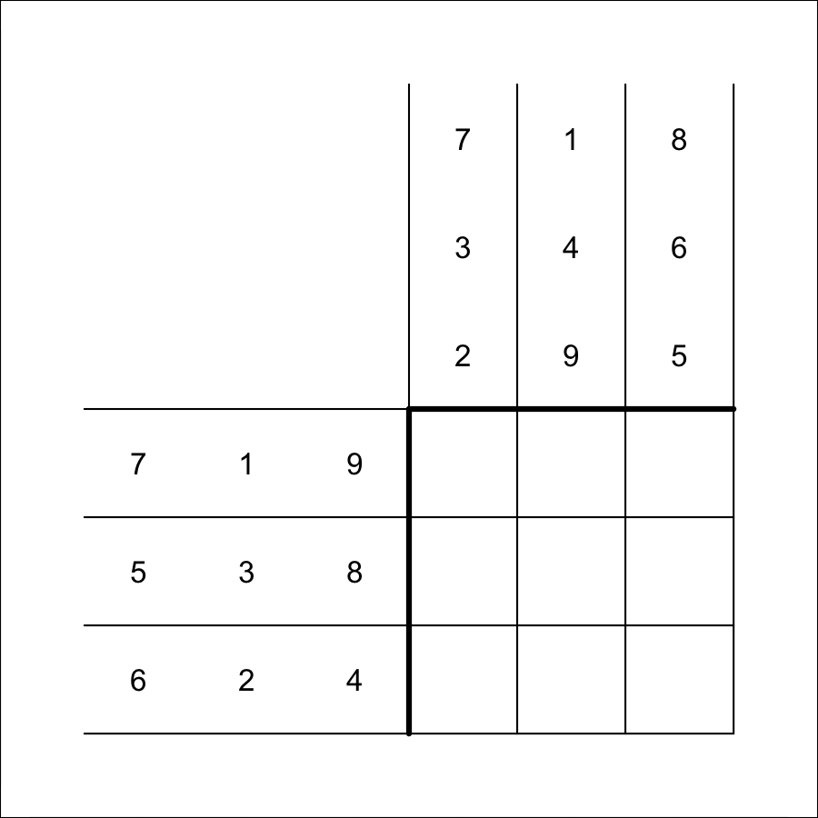

What is $c_{2,1}$?

To find $c_{2,1}$, you use row 2 from matrix $A$ and column 1 from matrix $B$.

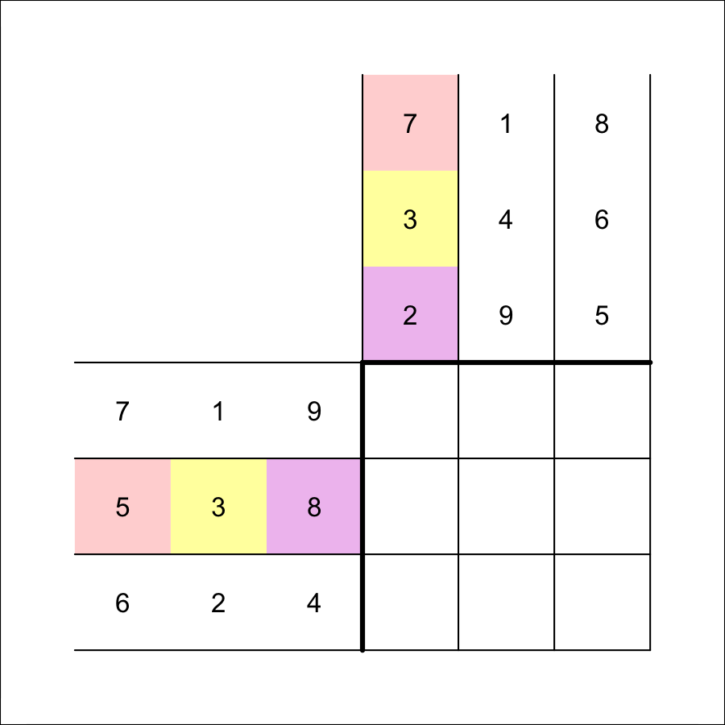

You multiply corresponding elements and sum those products.

$$c_{2,1}~=~( 5 \cdot 7 )+( 3 \cdot 3
)+( 8 \cdot 2 )$$

$$c_{2,1}~=~35+9+16$$

$$c_{2,1}~=~60$$

If you repeat this process for all 9 elements in $C$, you get:

$$\begin{bmatrix}
7 & 1 & 9\\
5 & 3 & 8\\
6 & 2 & 4
\end{bmatrix} \cdot \begin{bmatrix}
7 & 1 & 8\\
3 & 4 & 6\\
2 & 9 & 5
\end{bmatrix} ~=~ \begin{bmatrix}
70 & 92 & 107\\
60 & 89 & 98\\
56 & 50 & 80
\end{bmatrix}$$

Let matrices $A$ and $B$ be defined below.

$$A = \begin{bmatrix}
4 & 2 & 1\\
6 & 3 & 7\\
8 & 5 & 9
\end{bmatrix}$$
$$B = \begin{bmatrix}
9 & 6 & 3\\
7 & 5 & 4\\
2 & 8 & 1
\end{bmatrix}$$

A third matrix, $C$, is equal to the [product](https://en.wikipedia.org/wiki/Matrix_multiplication) $AB$. A student set up a diagram to help find the product:

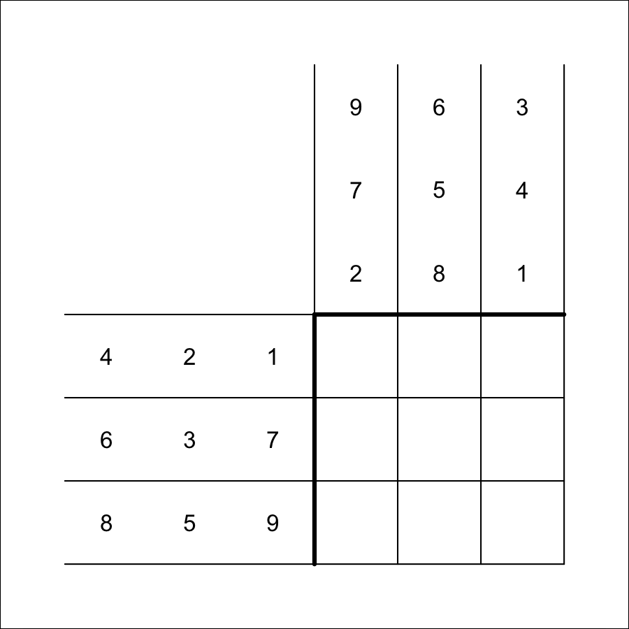

What is $c_{1,3}$?

To find $c_{1,3}$, you use row 1 from matrix $A$ and column 3 from matrix $B$.

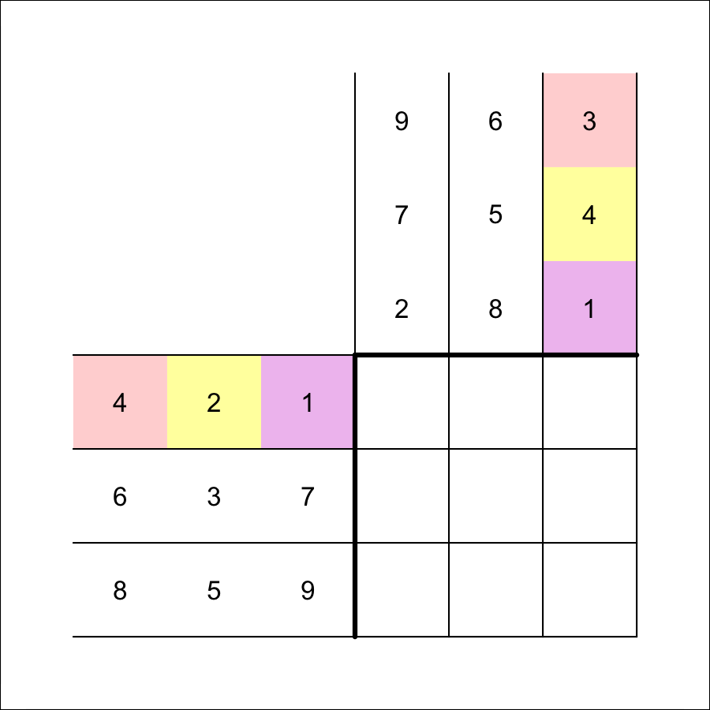

You multiply corresponding elements and sum those products.

$$c_{1,3}~=~( 4 \cdot 3 )+( 2 \cdot 4
)+( 1 \cdot 1 )$$

$$c_{1,3}~=~12+8+1$$

$$c_{1,3}~=~21$$

If you repeat this process for all 9 elements in $C$, you get:

$$\begin{bmatrix}
4 & 2 & 1\\
6 & 3 & 7\\
8 & 5 & 9
\end{bmatrix} \cdot \begin{bmatrix}
9 & 6 & 3\\
7 & 5 & 4\\
2 & 8 & 1
\end{bmatrix} ~=~ \begin{bmatrix}
52 & 42 & 21\\
89 & 107 & 37\\
125 & 145 & 53
\end{bmatrix}$$

Let matrices $A$ and $B$ be defined below.

$$A = \begin{bmatrix}
9 & 8 & 6\\
7 & 4 & 1\\
5 & 3 & 2
\end{bmatrix}$$
$$B = \begin{bmatrix}
4 & 5 & 6\\
8 & 1 & 2\\
7 & 3 & 9
\end{bmatrix}$$

A third matrix, $C$, is equal to the [product](https://en.wikipedia.org/wiki/Matrix_multiplication) $AB$. A student set up a diagram to help find the product:

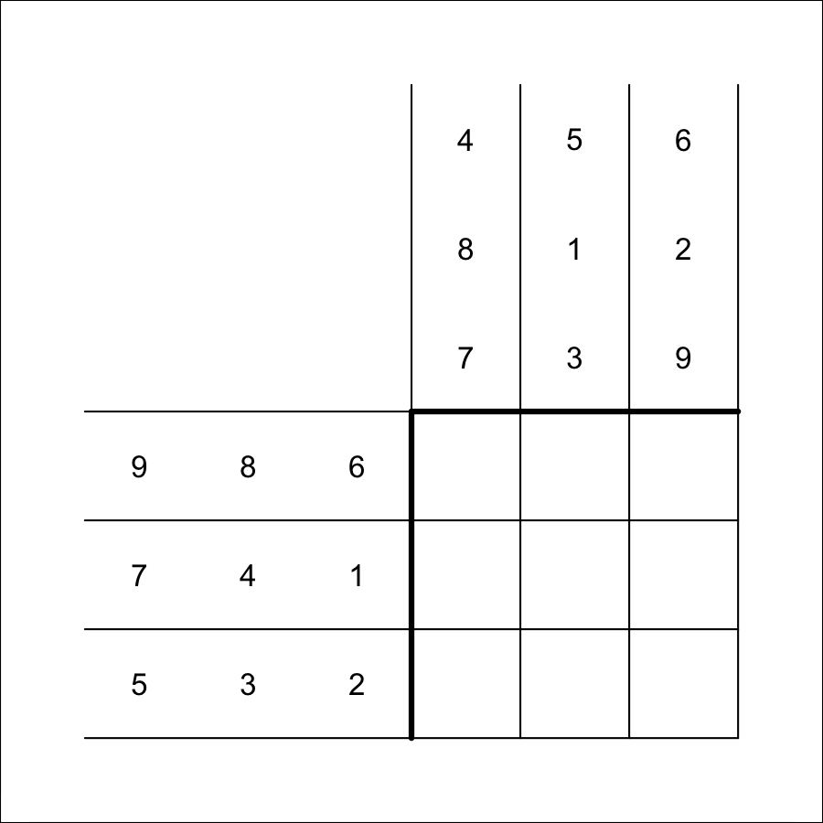

What is $c_{3,2}$?

To find $c_{3,2}$, you use row 3 from matrix $A$ and column 2 from matrix $B$.

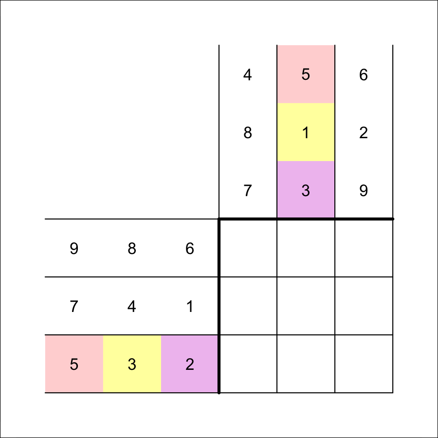

You multiply corresponding elements and sum those products.

$$c_{3,2}~=~( 5 \cdot 5 )+( 3 \cdot 1
)+( 2 \cdot 3 )$$

$$c_{3,2}~=~25+3+6$$

$$c_{3,2}~=~34$$

If you repeat this process for all 9 elements in $C$, you get:

$$\begin{bmatrix}
9 & 8 & 6\\
7 & 4 & 1\\
5 & 3 & 2
\end{bmatrix} \cdot \begin{bmatrix}
4 & 5 & 6\\
8 & 1 & 2\\
7 & 3 & 9
\end{bmatrix} ~=~ \begin{bmatrix}
142 & 71 & 124\\
67 & 42 & 59\\
58 & 34 & 54
\end{bmatrix}$$

Let matrices $A$ and $B$ be defined below.

$$A = \begin{bmatrix}
4 & 9 & 2\\
3 & 8 & 1\\
7 & 5 & 6
\end{bmatrix}$$
$$B = \begin{bmatrix}
2 & 1 & 7\\
3 & 9 & 4\\
8 & 6 & 5
\end{bmatrix}$$

A third matrix, $C$, is equal to the [product](https://en.wikipedia.org/wiki/Matrix_multiplication) $AB$. A student set up a diagram to help find the product:

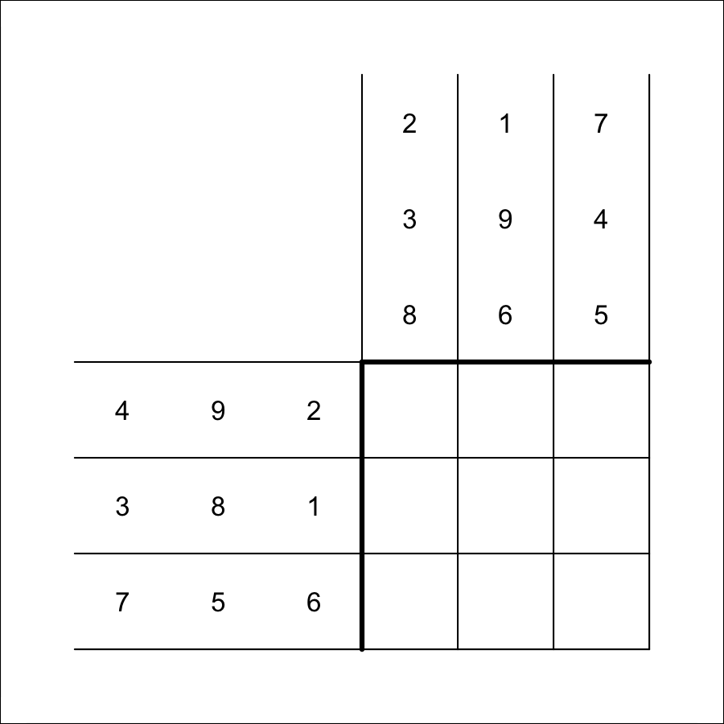

What is $c_{2,3}$?

To find $c_{2,3}$, you use row 2 from matrix $A$ and column 3 from matrix $B$.

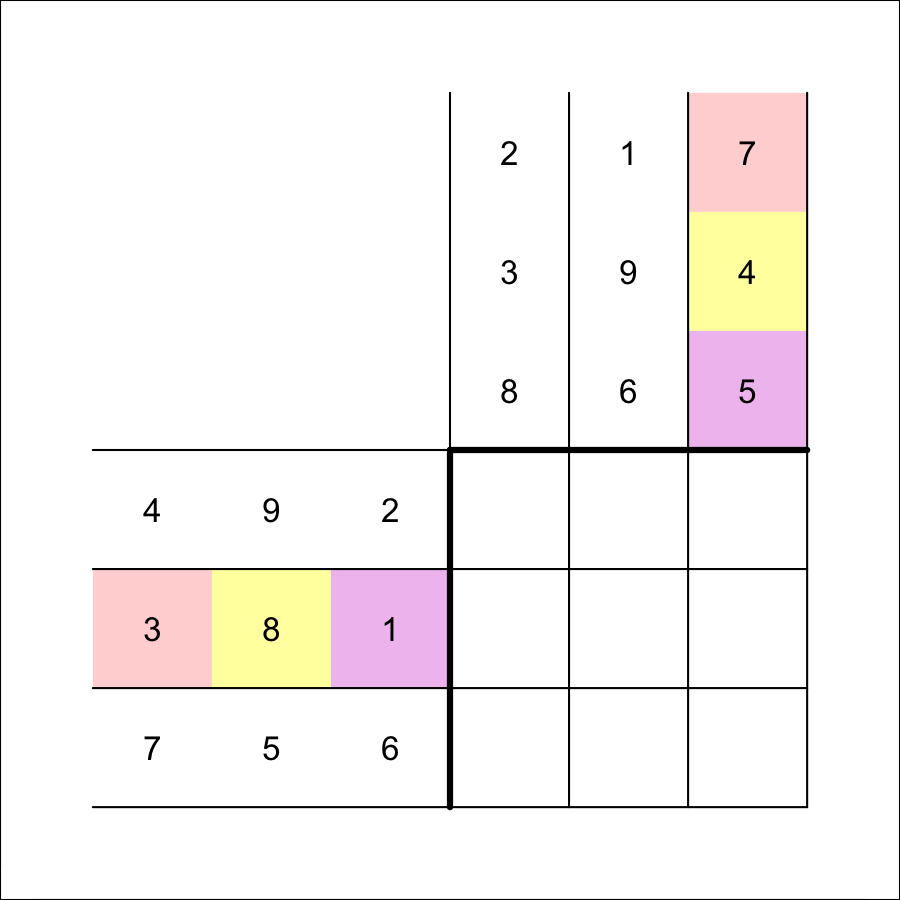

You multiply corresponding elements and sum those products.

$$c_{2,3}~=~( 3 \cdot 7 )+( 8 \cdot 4
)+( 1 \cdot 5 )$$

$$c_{2,3}~=~21+32+5$$

$$c_{2,3}~=~58$$

If you repeat this process for all 9 elements in $C$, you get:

$$\begin{bmatrix}
4 & 9 & 2\\
3 & 8 & 1\\
7 & 5 & 6
\end{bmatrix} \cdot \begin{bmatrix}
2 & 1 & 7\\
3 & 9 & 4\\
8 & 6 & 5
\end{bmatrix} ~=~ \begin{bmatrix}
51 & 97 & 74\\
38 & 81 & 58\\
77 & 88 & 99
\end{bmatrix}$$

Let matrices $A$ and $B$ be defined below.

$$A = \begin{bmatrix}
1 & 2 & 9\\
5 & 3 & 7\\
8 & 4 & 6
\end{bmatrix}$$
$$B = \begin{bmatrix}
4 & 7 & 3\\
1 & 6 & 8\\
2 & 9 & 5
\end{bmatrix}$$

A third matrix, $C$, is equal to the [product](https://en.wikipedia.org/wiki/Matrix_multiplication) $AB$. A student set up a diagram to help find the product:

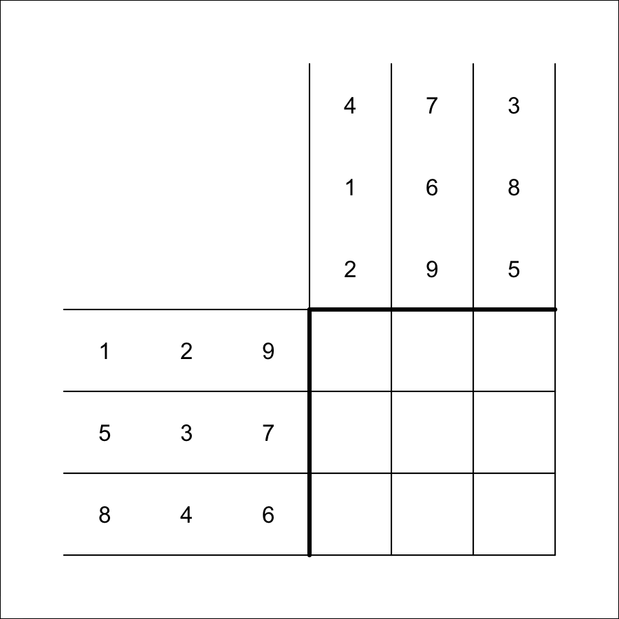

What is $c_{3,2}$?

To find $c_{3,2}$, you use row 3 from matrix $A$ and column 2 from matrix $B$.

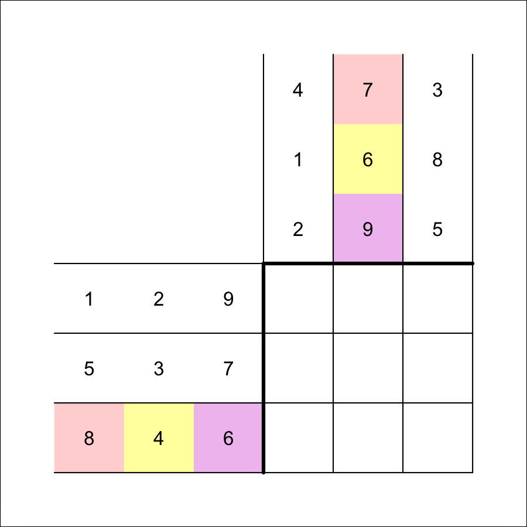

You multiply corresponding elements and sum those products.

$$c_{3,2}~=~( 8 \cdot 7 )+( 4 \cdot 6
)+( 6 \cdot 9 )$$

$$c_{3,2}~=~56+24+54$$

$$c_{3,2}~=~134$$

If you repeat this process for all 9 elements in $C$, you get:

$$\begin{bmatrix}
1 & 2 & 9\\
5 & 3 & 7\\
8 & 4 & 6
\end{bmatrix} \cdot \begin{bmatrix}
4 & 7 & 3\\
1 & 6 & 8\\
2 & 9 & 5
\end{bmatrix} ~=~ \begin{bmatrix}
24 & 100 & 64\\
37 & 116 & 74\\
48 & 134 & 86
\end{bmatrix}$$

Let matrices $A$ and $B$ be defined below.

$$A = \begin{bmatrix}
1 & 5 & 7\\
2 & 8 & 9\\
4 & 6 & 3
\end{bmatrix}$$
$$B = \begin{bmatrix}
4 & 5 & 2\\
8 & 1 & 7\\
3 & 6 & 9
\end{bmatrix}$$

A third matrix, $C$, is equal to the [product](https://en.wikipedia.org/wiki/Matrix_multiplication) $AB$. A student set up a diagram to help find the product:

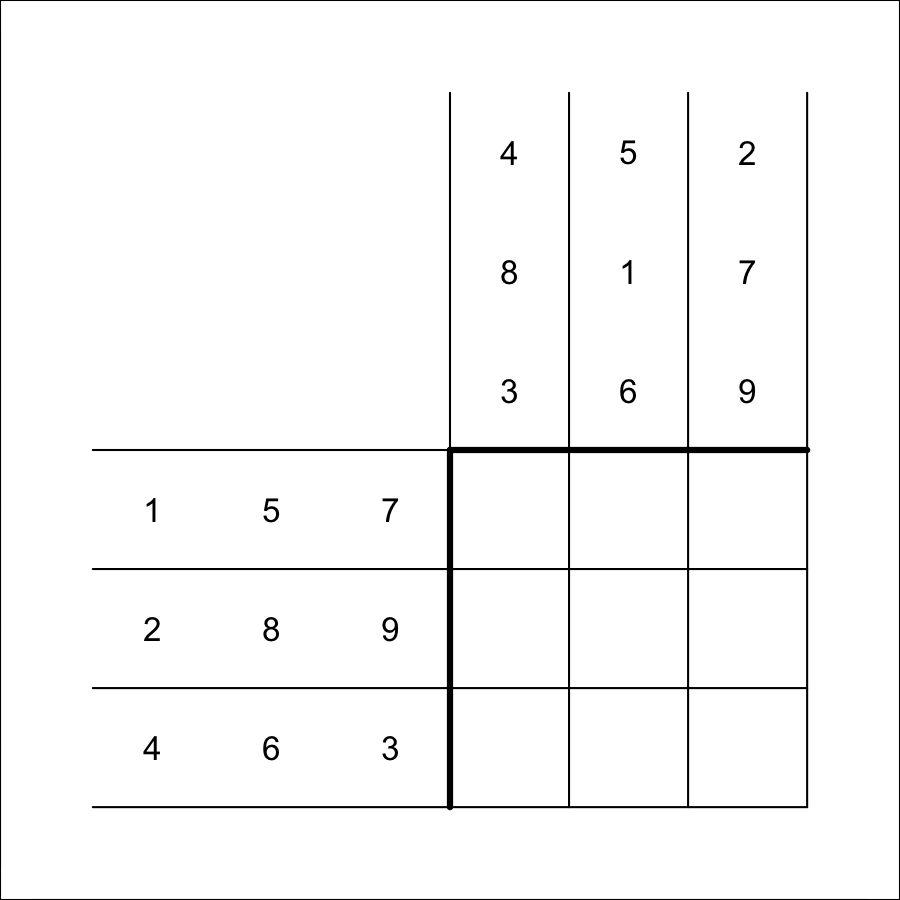

What is $c_{2,1}$?

To find $c_{2,1}$, you use row 2 from matrix $A$ and column 1 from matrix $B$.

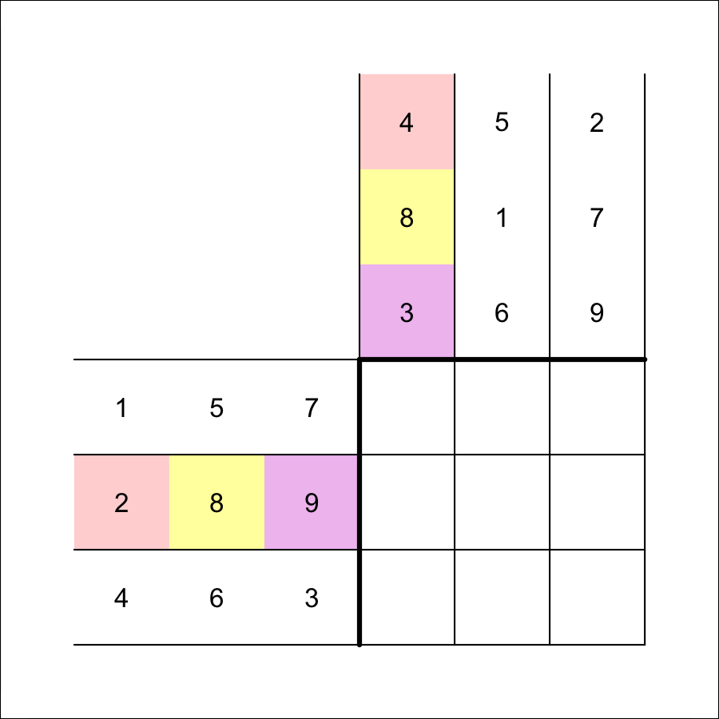

You multiply corresponding elements and sum those products.

$$c_{2,1}~=~( 2 \cdot 4 )+( 8 \cdot 8
)+( 9 \cdot 3 )$$

$$c_{2,1}~=~8+64+27$$

$$c_{2,1}~=~99$$

If you repeat this process for all 9 elements in $C$, you get:

$$\begin{bmatrix}
1 & 5 & 7\\
2 & 8 & 9\\
4 & 6 & 3
\end{bmatrix} \cdot \begin{bmatrix}
4 & 5 & 2\\
8 & 1 & 7\\
3 & 6 & 9
\end{bmatrix} ~=~ \begin{bmatrix}
65 & 52 & 100\\
99 & 72 & 141\\
73 & 44 & 77
\end{bmatrix}$$

Let matrices $A$ and $B$ be defined below.

$$A = \begin{bmatrix}
8 & 1 & 5\\
2 & 7 & 3\\
4 & 6 & 9
\end{bmatrix}$$
$$B = \begin{bmatrix}
7 & 5 & 1\\
4 & 2 & 9\\
6 & 8 & 3
\end{bmatrix}$$

A third matrix, $C$, is equal to the [product](https://en.wikipedia.org/wiki/Matrix_multiplication) $AB$. A student set up a diagram to help find the product:

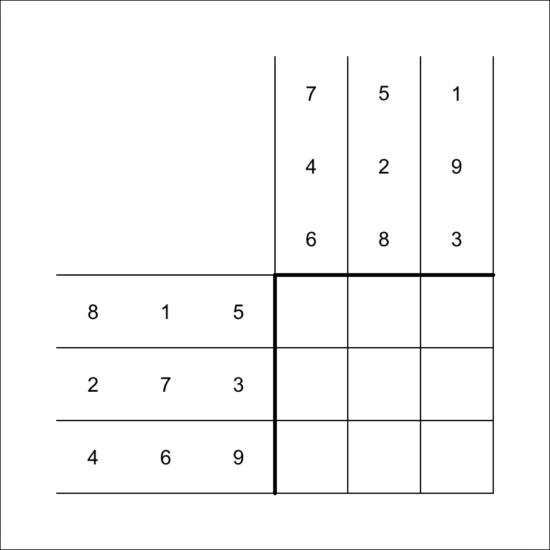

What is $c_{3,2}$?

To find $c_{3,2}$, you use row 3 from matrix $A$ and column 2 from matrix $B$.

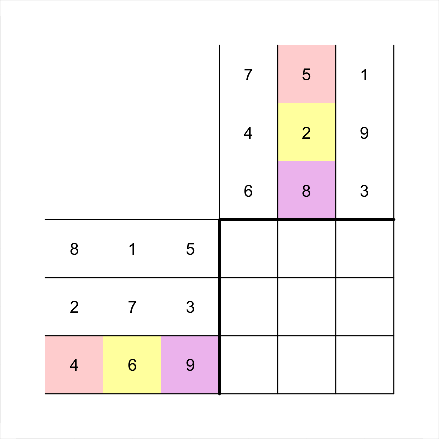

You multiply corresponding elements and sum those products.

$$c_{3,2}~=~( 4 \cdot 5 )+( 6 \cdot 2
)+( 9 \cdot 8 )$$

$$c_{3,2}~=~20+12+72$$

$$c_{3,2}~=~104$$

If you repeat this process for all 9 elements in $C$, you get:

$$\begin{bmatrix}
8 & 1 & 5\\
2 & 7 & 3\\
4 & 6 & 9
\end{bmatrix} \cdot \begin{bmatrix}
7 & 5 & 1\\
4 & 2 & 9\\
6 & 8 & 3
\end{bmatrix} ~=~ \begin{bmatrix}
90 & 82 & 32\\
60 & 48 & 74\\
106 & 104 & 85
\end{bmatrix}$$

Find the unknown element in the product matrix shown below:

$$\begin{bmatrix}
3 & 3 & 1\\
-4 & 2 & -4\\
-3 & 4 & -2
\end{bmatrix} \cdot \begin{bmatrix}
2 & -2 & -5\\
2 & 1 & -3\\
-1 & 2 & -4
\end{bmatrix} = \begin{bmatrix}
11 & -1 & -28\\
0 & 2 & ?\\
4 & 6 & 11
\end{bmatrix}$$

Notice, the unknown element is in the second row and third column. To calculate it, you'll need to find the sum of the pairwise products of the second row from the first matrix and the third column of the second matrix.

Find the unknown element in the product matrix shown below:

$$\begin{bmatrix}
-4 & -3 & 3\\
-3 & -1 & -3\\
5 & -3 & -6
\end{bmatrix} \cdot \begin{bmatrix}
5 & -4 & 3\\
-1 & 2 & 1\\
3 & 4 & 5
\end{bmatrix} = \begin{bmatrix}
-8 & 22 & 0\\
-23 & -2 & -25\\
10 & ? & -18
\end{bmatrix}$$

Notice, the unknown element is in the third row and second column. To calculate it, you'll need to find the sum of the pairwise products of the third row from the first matrix and the second column of the second matrix.

Find the unknown element in the product matrix shown below:

$$\begin{bmatrix}
-3 & -2 & 5\\
-6 & 4 & -5\\
-5 & 5 & 5
\end{bmatrix} \cdot \begin{bmatrix}
4 & -2 & -3\\
-3 & 2 & -1\\
-6 & 5 & 4
\end{bmatrix} = \begin{bmatrix}
-36 & 27 & ?\\
-6 & -5 & -6\\
-65 & 45 & 30
\end{bmatrix}$$

Notice, the unknown element is in the first row and third column. To calculate it, you'll need to find the sum of the pairwise products of the first row from the first matrix and the third column of the second matrix.

Find the unknown element in the product matrix shown below:

$$\begin{bmatrix}
-2 & -4 & -6\\
-5 & -1 & -5\\
-4 & -3 & 6
\end{bmatrix} \cdot \begin{bmatrix}
-3 & 2 & 4\\
2 & 5 & -6\\
3 & 5 & -3
\end{bmatrix} = \begin{bmatrix}
-20 & -54 & 34\\
-2 & -40 & 1\\
24 & ? & -16
\end{bmatrix}$$

Notice, the unknown element is in the third row and second column. To calculate it, you'll need to find the sum of the pairwise products of the third row from the first matrix and the second column of the second matrix.

Find the unknown element in the product matrix shown below:

$$\begin{bmatrix}
1 & -5 & 3\\
5 & 4 & 1\\
4 & -2 & 2
\end{bmatrix} \cdot \begin{bmatrix}
1 & 6 & 1\\
-6 & -2 & 6\\
3 & 2 & -6
\end{bmatrix} = \begin{bmatrix}
40 & 22 & -47\\
-16 & 24 & ?\\
22 & 32 & -20
\end{bmatrix}$$

Notice, the unknown element is in the second row and third column. To calculate it, you'll need to find the sum of the pairwise products of the second row from the first matrix and the third column of the second matrix.

Find the unknown element in the product matrix shown below:

$$\begin{bmatrix}
-1 & 1 & 5\\
6 & 3 & -5\\
-3 & -4 & 2
\end{bmatrix} \cdot \begin{bmatrix}
1 & -6 & 5\\
2 & 5 & -2\\
-6 & 2 & -6
\end{bmatrix} = \begin{bmatrix}
-29 & 21 & -37\\
42 & -31 & 54\\
? & 2 & -19
\end{bmatrix}$$

Notice, the unknown element is in the third row and first column. To calculate it, you'll need to find the sum of the pairwise products of the third row from the first matrix and the first column of the second matrix.

Find the unknown element in the product matrix shown below:

$$\begin{bmatrix}
1 & -6 & 3\\
4 & 6 & 2\\
5 & -6 & 5
\end{bmatrix} \cdot \begin{bmatrix}
4 & 3 & 6\\
1 & 4 & 6\\
1 & 3 & -4
\end{bmatrix} = \begin{bmatrix}
1 & -12 & -42\\
24 & 42 & 52\\
19 & ? & -26
\end{bmatrix}$$

Notice, the unknown element is in the third row and second column. To calculate it, you'll need to find the sum of the pairwise products of the third row from the first matrix and the second column of the second matrix.

Find the unknown element in the product matrix shown below:

$$\begin{bmatrix}
1 & 1 & -4\\
-3 & -4 & -1\\
-6 & 5 & 2
\end{bmatrix} \cdot \begin{bmatrix}
-5 & 6 & -4\\
2 & 2 & 1\\
3 & 1 & 4
\end{bmatrix} = \begin{bmatrix}
-15 & 4 & ?\\
4 & -27 & 4\\
46 & -24 & 37
\end{bmatrix}$$

Notice, the unknown element is in the first row and third column. To calculate it, you'll need to find the sum of the pairwise products of the first row from the first matrix and the third column of the second matrix.

Find the unknown element in the product matrix shown below:

$$\begin{bmatrix}
3 & 4 & 3\\
5 & 1 & 1\\
-5 & -4 & 6
\end{bmatrix} \cdot \begin{bmatrix}
-6 & 4 & 4\\
6 & 4 & -2\\
5 & 5 & -3
\end{bmatrix} = \begin{bmatrix}
21 & 43 & -5\\
-19 & 29 & ?\\
36 & -6 & -30
\end{bmatrix}$$

Notice, the unknown element is in the second row and third column. To calculate it, you'll need to find the sum of the pairwise products of the second row from the first matrix and the third column of the second matrix.

Find the unknown element in the product matrix shown below:

$$\begin{bmatrix}
1 & -2 & -4\\
2 & -4 & -3\\
1 & -2 & -2
\end{bmatrix} \cdot \begin{bmatrix}
-3 & -1 & -1\\
-3 & 3 & 5\\
-5 & 4 & 3
\end{bmatrix} = \begin{bmatrix}
23 & ? & -23\\
21 & -26 & -31\\
13 & -15 & -17
\end{bmatrix}$$

Notice, the unknown element is in the first row and second column. To calculate it, you'll need to find the sum of the pairwise products of the first row from the first matrix and the second column of the second matrix.

Find the unknown element in the product matrix shown below:

$$\begin{bmatrix}
-5 & -5 & 2\\
3 & 5 & -2\\
-5 & 4 & -1
\end{bmatrix} \cdot \begin{bmatrix}
4 & -4 & -4\\
5 & 6 & -1\\
-3 & 1 & -4
\end{bmatrix} = \begin{bmatrix}
-51 & -8 & 17\\
43 & 16 & -9\\
3 & ? & 20
\end{bmatrix}$$

Notice, the unknown element is in the third row and second column. To calculate it, you'll need to find the sum of the pairwise products of the third row from the first matrix and the second column of the second matrix.

Find the unknown element in the product matrix shown below:

$$\begin{bmatrix}
-2 & -4 & -4\\
-5 & -5 & 5\\
4 & -1 & 3
\end{bmatrix} \cdot \begin{bmatrix}
1 & -2 & 4\\
-1 & -1 & 3\\
1 & 6 & -4
\end{bmatrix} = \begin{bmatrix}
-2 & -16 & ?\\
5 & 45 & -55\\
8 & 11 & 1
\end{bmatrix}$$

Notice, the unknown element is in the first row and third column. To calculate it, you'll need to find the sum of the pairwise products of the first row from the first matrix and the third column of the second matrix.

Find the unknown element in the product matrix shown below:

$$\begin{bmatrix}
4 & 2 & 2\\
5 & -2 & 4\\
1 & -4 & 5
\end{bmatrix} \cdot \begin{bmatrix}
-2 & 5 & -1\\
-3 & 5 & -1\\
5 & 3 & -5
\end{bmatrix} = \begin{bmatrix}
-4 & 36 & -16\\
16 & 27 & -23\\
? & 0 & -22
\end{bmatrix}$$

Notice, the unknown element is in the third row and first column. To calculate it, you'll need to find the sum of the pairwise products of the third row from the first matrix and the first column of the second matrix.

Find the unknown element in the product matrix shown below:

$$\begin{bmatrix}
-1 & -3 & 6\\
3 & 1 & 5\\
1 & 1 & -5
\end{bmatrix} \cdot \begin{bmatrix}
5 & -2 & 6\\
3 & -4 & -4\\
4 & -2 & 6
\end{bmatrix} = \begin{bmatrix}
10 & 2 & ?\\
38 & -20 & 44\\
-12 & 4 & -28
\end{bmatrix}$$

Notice, the unknown element is in the first row and third column. To calculate it, you'll need to find the sum of the pairwise products of the first row from the first matrix and the third column of the second matrix.

Find the unknown element in the product matrix shown below:

$$\begin{bmatrix}
-2 & 4 & 4\\
2 & -2 & 3\\
1 & 4 & -4
\end{bmatrix} \cdot \begin{bmatrix}
-1 & -2 & -2\\
-4 & 5 & -1\\
-2 & -2 & 4
\end{bmatrix} = \begin{bmatrix}
-22 & 16 & 16\\
0 & -20 & 10\\
? & 26 & -22
\end{bmatrix}$$

Notice, the unknown element is in the third row and first column. To calculate it, you'll need to find the sum of the pairwise products of the third row from the first matrix and the first column of the second matrix.

Find the unknown element in the product matrix shown below:

$$\begin{bmatrix}
3 & 5 & -5\\
6 & -5 & 6\\
5 & -4 & -1
\end{bmatrix} \cdot \begin{bmatrix}
3 & 3 & -5\\
-1 & -4 & -1\\
-1 & 3 & -6
\end{bmatrix} = \begin{bmatrix}
9 & -26 & 10\\
17 & 56 & -61\\
20 & ? & -15
\end{bmatrix}$$

Notice, the unknown element is in the third row and second column. To calculate it, you'll need to find the sum of the pairwise products of the third row from the first matrix and the second column of the second matrix.

Find the unknown element in the product matrix shown below:

$$\begin{bmatrix}
5 & 3 & -1\\
2 & -1 & -2\\
-2 & 2 & -3
\end{bmatrix} \cdot \begin{bmatrix}
1 & -5 & 3\\
4 & -6 & 5\\
-4 & 4 & -3
\end{bmatrix} = \begin{bmatrix}
21 & -47 & 33\\
6 & -12 & ?\\
18 & -14 & 13
\end{bmatrix}$$

Notice, the unknown element is in the second row and third column. To calculate it, you'll need to find the sum of the pairwise products of the second row from the first matrix and the third column of the second matrix.

Find the unknown element in the product matrix shown below:

$$\begin{bmatrix}
2 & 3 & 6\\
-4 & -1 & 6\\
-5 & 6 & -5
\end{bmatrix} \cdot \begin{bmatrix}
3 & 5 & 2\\
5 & -2 & -6\\
-3 & -1 & 1
\end{bmatrix} = \begin{bmatrix}
3 & -2 & -8\\
-35 & -24 & 4\\
? & -32 & -51
\end{bmatrix}$$

Notice, the unknown element is in the third row and first column. To calculate it, you'll need to find the sum of the pairwise products of the third row from the first matrix and the first column of the second matrix.

Find the unknown element in the product matrix shown below:

$$\begin{bmatrix}
6 & 3 & -3\\
3 & -3 & -1\\
-1 & -6 & 2
\end{bmatrix} \cdot \begin{bmatrix}
-6 & 4 & 4\\
2 & -2 & 4\\
2 & -3 & 3
\end{bmatrix} = \begin{bmatrix}
-36 & 27 & 27\\
-26 & 21 & -3\\
-2 & ? & -22
\end{bmatrix}$$

Notice, the unknown element is in the third row and second column. To calculate it, you'll need to find the sum of the pairwise products of the third row from the first matrix and the second column of the second matrix.

Find the unknown element in the product matrix shown below:

$$\begin{bmatrix}
4 & -6 & 6\\
1 & 6 & 6\\
-6 & 2 & -6
\end{bmatrix} \cdot \begin{bmatrix}
3 & -6 & 3\\
-2 & -3 & -1\\
3 & 2 & 5
\end{bmatrix} = \begin{bmatrix}
42 & ? & 48\\
9 & -12 & 27\\
-40 & 18 & -50
\end{bmatrix}$$

Notice, the unknown element is in the first row and second column. To calculate it, you'll need to find the sum of the pairwise products of the first row from the first matrix and the second column of the second matrix.

A matrix is a rectangular array of numbers. The dimensions of a matrix represent the number of rows and the number of columns (in that order!). Find the dimensions of the matrix below.

$$\begin{bmatrix}
4 & 0 & -5 & -3 & 2 & 7\\
-1 & -5 & 5 & -7 & -1 & -3\\
-7 & 5 & -7 & -8 & -9 & -8\\
-9 & 4 & 3 & -4 & 8 & -6
\end{bmatrix}$$

Dimensions: $\times$

There are 4 rows and 6 columns. We say, "It is a 4 by 6 matrix." We write the dimensions as 4 $\times$ 6.

A matrix is a rectangular array of numbers. The dimensions of a matrix represent the number of rows and the number of columns (in that order!). Find the dimensions of the matrix below.

$$\begin{bmatrix}
-4 & -4 & -1 & -2 & 9\\
4 & -6 & 7 & 7 & 4\\
-2 & -1 & 8 & -9 & 6\\
8 & -3 & -1 & -3 & 6\\
1 & 7 & -3 & -4 & 3\\
1 & -5 & -2 & 8 & 7
\end{bmatrix}$$

Dimensions: $\times$

There are 6 rows and 5 columns. We say, "It is a 6 by 5 matrix." We write the dimensions as 6 $\times$ 5.

A matrix is a rectangular array of numbers. The dimensions of a matrix represent the number of rows and the number of columns (in that order!). Find the dimensions of the matrix below.

$$\begin{bmatrix}
5 & -2 & -4 & -4 & -9 & 0 & 3\\
-5 & -7 & 5 & -8 & 9 & 7 & 1\\
-7 & 4 & 0 & 7 & 9 & -3 & -1\\
-1 & 7 & -6 & -9 & -4 & -1 & 9
\end{bmatrix}$$

Dimensions: $\times$

There are 4 rows and 7 columns. We say, "It is a 4 by 7 matrix." We write the dimensions as 4 $\times$ 7.

A matrix is a rectangular array of numbers. The dimensions of a matrix represent the number of rows and the number of columns (in that order!). Find the dimensions of the matrix below.

$$\begin{bmatrix}
6 & 7 & -4 & -2 & -2\\
9 & 2 & -9 & -3 & 7\\
3 & 4 & -4 & -8 & -6\\
3 & -7 & -5 & -3 & 5\\
-2 & -9 & 3 & 8 & -1\\
-2 & -3 & 0 & 7 & 4\\
5 & 5 & 6 & -3 & 4
\end{bmatrix}$$

Dimensions: $\times$

There are 7 rows and 5 columns. We say, "It is a 7 by 5 matrix." We write the dimensions as 7 $\times$ 5.

A matrix is a rectangular array of numbers. The dimensions of a matrix represent the number of rows and the number of columns (in that order!). Find the dimensions of the matrix below.

$$\begin{bmatrix}
6 & -7\\
8 & 6\\
-7 & 6\\
5 & -8\\
1 & -7\\
3 & -8\\
-6 & 3
\end{bmatrix}$$

Dimensions: $\times$

There are 7 rows and 2 columns. We say, "It is a 7 by 2 matrix." We write the dimensions as 7 $\times$ 2.

A matrix is a rectangular array of numbers. The dimensions of a matrix represent the number of rows and the number of columns (in that order!). Find the dimensions of the matrix below.

$$\begin{bmatrix}
-6 & -3\\
-9 & 0\\
-9 & 4\\
4 & -8\\
1 & -1\\
8 & -6
\end{bmatrix}$$

Dimensions: $\times$

There are 6 rows and 2 columns. We say, "It is a 6 by 2 matrix." We write the dimensions as 6 $\times$ 2.

A matrix is a rectangular array of numbers. The dimensions of a matrix represent the number of rows and the number of columns (in that order!). Find the dimensions of the matrix below.

$$\begin{bmatrix}
0 & -8 & 6 & -1 & -8\\
-2 & 5 & -8 & 7 & 4
\end{bmatrix}$$

Dimensions: $\times$

There are 2 rows and 5 columns. We say, "It is a 2 by 5 matrix." We write the dimensions as 2 $\times$ 5.

A matrix is a rectangular array of numbers. The dimensions of a matrix represent the number of rows and the number of columns (in that order!). Find the dimensions of the matrix below.

$$\begin{bmatrix}
9 & -3\\
-3 & 9\\
1 & 4
\end{bmatrix}$$

Dimensions: $\times$

There are 3 rows and 2 columns. We say, "It is a 3 by 2 matrix." We write the dimensions as 3 $\times$ 2.

A matrix is a rectangular array of numbers. The dimensions of a matrix represent the number of rows and the number of columns (in that order!). Find the dimensions of the matrix below.

$$\begin{bmatrix}
-6 & -9 & -9 & 9 & -2\\
-3 & -5 & -2 & -3 & 2\\
8 & 3 & -3 & -5 & -8
\end{bmatrix}$$

Dimensions: $\times$